# Changepoint for Fatigue Paper

Amir Baghdadi[^1]

Lora A. Cavuoto[^2]

Allison Jones-Farmer[^3]

Steve Rigdon[^4]

Fadel M. Megahed[^5]

October 24, 2018

In this paper, we attempt to examine whether the use of change-point analysis techniques is appropriate for detecting fatigue based on data captured from wearable sensors. As such, we perform a **secondary data analysis** to the data generated in: [Baghdadi et al., 2018](https://www.tandfonline.com/doi/full/10.1080/00140139.2018.1442936). The reader should note that their raw data was preprocessed using:

1. *Kalman Filter:* Used to process the raw data from sensors to: (i) estimate the spatial orientation of the body with respect to the global reference frame, and (ii) to estimate the kinematics of motion.
2. *Segmentation:* The motion segments where then segmented using an algorithm that assumes the existence of two peaks in the translational acceleration of the gait cycle. This assumption was justified based on the results of [Tongen and Wunderlich, 2010](https://www.cambridge.org/core/books/mathematics-and-sports/biomechanics-of-running-and-walking/0DC334F72A56527FC4517B297923E9D3) as well as the authors’ preliminary analyses.

The reader can **show** any code chunk by clicking on the *code* button. We chose to make the default for the code hidden since we: (a) wanted to improve the readability of this document; and (b) assumed that the readers will not be interested in reading every code chunk.

# 1 Loading Data & Generating Features

The snippet below documents the list of **R** libraries that were used in this research. For convenience, we used the pacman package since it allows for installing/loading the needed libraries in one step.

```r
rm(list = ls()) # clear global environment
graphics.off() # close all graphics
library(pacman) # needs to be installed first
p_load(R.matlab, plotly, extrafont, grDevices, gridExtra,
       dplyr, stringr, tidyverse, utils, reshape2,
       anomalize, MVN, forecast, fractal,
       ecp, dfphase1,
       MALDIquant, TSclust,
       knitr, kableExtra, dplyr)
```

In the snippet below, we extract the 15 “.mat” files in the [GitHub repository](https://github.com/fmegahed/fatigue-changepoint/tree/master/Data/Raw) (where we loaded the data to allow for the reproduction of our work). Note that these files were originally produced in [Baghdadi et al., 2018](https://www.tandfonline.com/doi/abs/10.1080/00140139.2018.1442936?). Then, we perform several transformation steps: (a) extracting the data for the first three columns in the matlab arrays; and (b) computing three kinematic features from the data corresponding to these columns. Due to the differences between Matlab and R, this requires two nested *for* loops. The outer loop increments over the number of subjects, while the inner loop increments based on the different number of rows of data for each subject. Please see the comments within the code chunk for more details.

```r
num_subjects <- seq(1, 15)
subject_heights <- c(1.71, 1.77, 1.71, 1.59, 1.69,
                     1.63, 1.60, 1.71, 1.67, 1.78,
                     1.68, 1.55, 1.83, 1.81, 1.89)

# Initilizing a df for summary data on participants
summary_df <- data.frame(matrix(nrow = 15, ncol = 9))
colnames(summary_df) <- c("Subject.Num", "num.rows",
                          "num.cols", "mean.scaled.stride.len",
                          "sd.scaled.stride.len",
                          "mean.scaled.stride.height",
                          "sd.scaled.stride.height",
                          "mean.stride.duration",
                          "sd.stride.duartion")

for (i in 1:length(num_subjects)) {
  # Reading the .mat files from GitHub
  raw_data <- readMat(paste0("https://github.com/fmegahed/fatigue-changepoint/blob/master/Data/Raw/Subject",num_subjects[i],".mat?raw=true"))
  # Compute the number of cells, and rows in each structered matrix
  raw_data_size <- lengths(raw_data) # num of cells
  num_rows <- raw_data_size / 17 # all data had 17 cols
  # Initilizing the six lists needed for storing the data (we keep track of the top 3 for error checking)
  time_in_sec <- vector("list", length = num_rows)
  position_x <- vector("list", length = num_rows)
  position_y <- vector("list", length = num_rows)
  stride_time <- vector("list", length = num_rows)
  stride_length <- vector("list", length = num_rows)
  stride_height <- vector("list", length = num_rows)
  stride_duration <- vector("list", length = num_rows)

  # Following for loop is needed since R reads the structured array as a nested list. The list containing the data is called "M.i.k" and it transforms/reads the original array --> rowise. This means that our first three features (with the same timestamp) are always seperated with a distance equal to the total number of rows
  for (j in 1:num_rows) {
    position_x[[j]] <- raw_data[["M.i.k"]][[j]]
    position_y[[j]] <- raw_data[["M.i.k"]][[num_rows + j]]
    stride_time[[j]] <- raw_data[["M.i.k"]][[2 * num_rows + j]]
    dataholder <- raw_data[["M.i.k"]][[16 * num_rows + j]] # data holder for time
    # Computing the three needed kinematic features
    stride_length[[j]] <-
      range(position_x[[j]])[2] - range(position_x[[j]])[1]
    stride_height[[j]] <-
      range(position_y[[j]])[2] - range(position_y[[j]])[1]
    stride_duration[[j]] <-
      range(stride_time[[j]])[2] - range(stride_time[[j]])[1]
    time_in_sec[[j]] <- lapply(dataholder, mean)# using mean time of stride as a time stamp
  }

  # Scaling and creating one data frame per subject
  assign(paste0("subject", i, "_features"),
         data.frame(time.from.start = unlist(time_in_sec),
                    scaled.stride.len = unlist(stride_length)/subject_heights[i],
                    scaled.stride.height = unlist(stride_height) / subject_heights[i],
                    stride.duration = unlist(stride_duration)
                    )
         )

  # Creating a Summary Data Frame
  df_name <- paste0("subject", i, "_features")
  summary_df[i, 1] <- paste0("subject", i)
  summary_df[i, 2] <- get(df_name) %>% nrow()
  summary_df[i, 3] <- get(df_name) %>% ncol()
  summary_df[i, 4] <- get(df_name)[, 2] %>% mean() %>% round(digits = 4)
  summary_df[i, 5] <- get(df_name)[, 2] %>% sd() %>% round(digits = 4)
  summary_df[i, 6] <- get(df_name)[, 3] %>% mean() %>% round(digits = 4)
  summary_df[i, 7] <- get(df_name)[, 3] %>% sd() %>% round(digits = 4)
  summary_df[i, 8] <- get(df_name)[, 4] %>% mean() %>% round(digits = 4)
  summary_df[i, 9] <- get(df_name)[, 4] %>% sd() %>% round(digits = 4)
}
# Printing the top six rows of Subject 4's data as an example
head(subject4_features) %>% round(digits = 3)
```

|  | time.from.start | scaled.stride.len | scaled.stride.height | stride.duration |
| --- | --- | --- | --- | --- |
| 1 | 1.494 | 1.537 | 0.178 | 0.801 |
| 2 | 2.334 | 1.459 | 0.153 | 0.801 |
| 3 | 3.203 | 1.940 | 0.102 | 0.859 |
| 4 | 4.072 | 1.420 | 0.167 | 0.801 |
| 5 | 4.912 | 1.472 | 0.182 | 0.801 |
| 6 | 5.752 | 1.521 | 0.184 | 0.801 |

```r
# A Summary of the features for all 15 participants
summary_df
```

| Subject.Num | num.rows | num.cols | mean.scaled.stride.len | sd.scaled.stride.len | mean.scaled.stride.height | sd.scaled.stride.height | mean.stride.duration | sd.stride.duartion |
| --- | --- | --- | --- | --- | --- | --- | --- | --- |
| subject1 | 4874 | 4 | 1.0658 | 0.1561 | 0.0920 | 0.0149 | 1.0592 | 0.0421 |
| subject2 | 5482 | 4 | 1.6282 | 0.2070 | 0.1281 | 0.0351 | 0.9484 | 0.0896 |
| subject3 | 1688 | 4 | 0.9404 | 0.1722 | 0.0911 | 0.0229 | 1.0856 | 0.0514 |
| subject4 | 7771 | 4 | 1.2758 | 0.2628 | 0.1237 | 0.0300 | 0.9450 | 0.0920 |
| subject5 | 3655 | 4 | 0.9624 | 0.2185 | 0.0877 | 0.0235 | 1.0852 | 0.0717 |
| subject6 | 5644 | 4 | 0.9076 | 0.1900 | 0.1081 | 0.0199 | 1.0599 | 0.0512 |
| subject7 | 3549 | 4 | 0.8382 | 0.1620 | 0.0924 | 0.0264 | 1.1250 | 0.0666 |
| subject8 | 7519 | 4 | 1.5345 | 0.2756 | 0.1382 | 0.0343 | 0.9760 | 0.0671 |
| subject9 | 5710 | 4 | 0.8736 | 0.2028 | 0.1009 | 0.0250 | 1.1083 | 0.0701 |
| subject10 | 6719 | 4 | 1.2766 | 0.3177 | 0.1101 | 0.0330 | 1.0050 | 0.0725 |

[output cut: 5 more lines]

```r
rm(raw_data, raw_data_size, i, j, num_rows,
   dataholder, num_subjects)
save.image(file = "./Data/RGenerated/FeatureGeneration.RData")
```

Based on the analysis above, there are **three observations** to be made. *First*, we scaled the stride length and height based on the subject’s height. This in essence allows us to capture the steps as a percentage of the person’s height. This reduces the between subject variablity in the data and is supported by the seminal work of [Oberg et al., 1993](http://citeseerx.ist.psu.edu/viewdoc/download?doi=10.1.1.473.947&rep=rep1&type=pdf). *Second*, we showed the first six rows from Subject 4 to provide the reader with some insights into the sampling frequeny (after the preprocessing done in [Baghdadi et al. 2018](https://www.tandfonline.com/doi/abs/10.1080/00140139.2018.1442936)). Note that the kinematic features are computed from the sensor channels provided in their paper. *Third*, we saved the generated data into an R.data file, which can be accessed by clicking on: FeatureGeneration.RData. We hope that this saved data allows other researchers to reproduce and/or build on our work.

# 2 Implementation of the Filtering and Data Preprocessing

After examining several outlier detection methods, i.e., boxplots for outlier detection and Mahalanobis distance based methods, our final approach to detecting and then removing outliers is to use smoothing techniques to “correct” the data. Based on the results shown in the previous sections, the fundamental hypotheses behind this approach are:

1. The sensors’ data seem to be non-stationary, autocorrelated and somewhat complex (from a statistical perspective). More importantly, there are spikes in the data that cannot be explained by the kinematic model. These spikes produce values that are unrealistic (e.g., a scaled stride length > 2 is not possible since that means that the stride of the person is two times larger than their height). While this insight is useful, there is no hard limit that we can enforce since the literature reports mean values across the population instead of attempting to provide a physical threshold on what is possible.
2. The outliers tended to appear in pairs of two; indicating a possible issue in the segmentation of the data. Note that we label this data as outliers since it is not sustained (i.e., it is unlikely to say that a person is fatigued for only two stride).
3. Smoothing (i.e. a low pass filter on the data) will allow us to impute values for every stride (after an initial size window). This will allow us to preserve the successive nature of the strides, “fix” the outliers based on neighboring strides, and not throw away any observation.

## 2.1 The Median Filtering Approach from the Signal Processing Literature

An algorithmic approach based on these observations is implemented below. Note that we are using the [median filter](https://onlinelibrary.wiley.com/doi/book/10.1002/9780470740156) from the [fractal package](https://cran.r-project.org/web/packages/fractal/fractal.pdf) on CRAN. Note that in the analysis below, we are applying the *median Filter*, with n=29 (i.e., the median is calculated based on a overlaping moving window of size 29 strides). We chose this window size based on the recommendation of our biomechanics expert as it allows us to: (a) ignore the effect of any turns in the direction of motion; and (b) the corresponding window size is approximately 30 seconds long (which presents an easy to remember rule for practical application).

```r
# We are reading the data locally (you can download the file from GitHub)
load(file = "./Data/RGenerated/FeatureGeneration.RData")
for (i in 1:15) {
  df <- get(paste0("subject",i,"_features")) # Getting Data from Sec.
  # Obtaining the Outliers for each of the three variables
  time.from.start <- df[,1]
  scaled.stride.len <- medianFilter(df[,2], order = 29) # moving window of size 29 obs
  scaled.stride.height <- medianFilter(df[,3], order = 29) # moving window of size 29 obs
  stride.duration <- medianFilter(df[,4], order = 29) # moving window of size 29 obs

  # Computing the first difference to make seein the values easier
  diff.time.from.start <- time.from.start[-1]
  diff.scaled.stride.len <- diff(scaled.stride.len)
  diff.scaled.stride.height <- diff(scaled.stride.height)
  diff.stride.duration <- diff(stride.duration)
  # Remove the observations corresponding to the outliers
  assign(paste0("subject",i,"_medianf"),
         data.frame(cbind(time.from.start, scaled.stride.len,
                          scaled.stride.height, stride.duration)))

  assign(paste0("subject",i,"_median_diff_f"),
         data.frame(cbind( diff.time.from.start, diff.scaled.stride.len,
                          diff.scaled.stride.height, diff.stride.duration)))

}

  cat('<source> <p> The data processed with the median filtered approach is stored at the <a href="https://github.com/fmegahed/fatigue-changepoint/blob/master/Data/RGenerated/MedianFilteredData.RData">following location</a> in our GitHub Repository.')
```

The data processed with the median filtered approach is stored at the [following location](https://github.com/fmegahed/fatigue-changepoint/blob/master/Data/RGenerated/MedianFilteredData.RData) in our GitHub Repository.

```r
  cat('\n \n')
```

```r
# Saving a list of cleaned
save(subject1_medianf, subject2_medianf, subject3_medianf, subject4_medianf,
     subject5_medianf, subject6_medianf, subject7_medianf, subject8_medianf,
     subject9_medianf, subject10_medianf, subject11_medianf, subject12_medianf,
     subject13_medianf, subject14_medianf, subject15_medianf,
     subject1_median_diff_f, subject2_median_diff_f, subject3_median_diff_f,
     subject4_median_diff_f,
     subject5_median_diff_f, subject6_median_diff_f, subject7_median_diff_f,
     subject8_median_diff_f,
     subject9_median_diff_f, subject10_median_diff_f, subject11_median_diff_f,
     subject12_median_diff_f,
     subject13_median_diff_f, subject14_median_diff_f, subject15_median_diff_f,
     file = "./Data/RGenerated/MedianFilteredData.RData")
```

## 2.2 Applying the Median Filter Methodology on the CUSUM of the Features

```r
  load(file = "./Data/RGenerated/MedianFilteredData.RData")
  for (i in 1:15) {
    df <- get(paste0("subject",i,"_medianf"))
  means <- colMeans(df)
  df[,2] <- cumsum(df[,2]-means[2])
  df[,3] <- cumsum(df[,3]-means[3])
  df[,4] <- cumsum(df[,4]-means[4])
  assign(paste0("subject",i,"_cusum"), df)

  }

 cat('<source> <p> The results from the analysis above can be found at: <a href="https://github.com/fmegahed/fatigue-changepoint/blob/master/Data/RGenerated/CusumData.RData">CusumData.RData</a>. </p> </source>')
```

The results from the analysis above can be found at: CusumData.RData.

```r
  cat('\n \n')
```

```r
save(subject1_cusum, subject2_cusum, subject3_cusum,
     subject4_cusum, subject5_cusum, subject6_cusum,
     subject7_cusum, subject8_cusum, subject9_cusum,
     subject10_cusum, subject11_cusum, subject12_cusum,
     subject13_cusum, subject14_cusum, subject15_cusum,
       file = "./Data/RGenerated/CusumData.RData")
```

## 2.3 Using %Time-from-Start to Standardize the Length of Each Participant’s Time-series

In this section, we rescale/normalize the timescale a 0-100% scale for all participants to prepare for a timeseries clustering type analysis. Specifically, we sampled the three features from the data based on a 0.05% from start. This resulted in a standardization of the number of observations within each timeseries across our 15 paricipants. Based on our increment size, each timeseries is now comprised of 2000 observations, each at 0.05% time increment from its neighouring data points.

```r
# to load previously generated data
load(file = "./Data/RGenerated/FeatureGeneration.RData")

medianfilt_norm <- list()
cusum_norm <- list()

for (i in 1:15) {

  df <- get(paste0("subject",i,"_features")) # Getting Data from Sec.

  # resampling the data to 2000 samples
  nsamples = 2000
  timePerc <- seq(0, 100, by=0.05)
  timeScale <- df[nrow(df),1]/nsamples
  df_norm = df[FALSE,]

  for (j in 1:nsamples) {
    df_matchIsx <- match.closest(timeScale*(j-0.5),df[,1]) # finding the closest point
    df_keep <- df[df_matchIsx,]
    df_keep[,1] <- timePerc[j]
    df_norm <- rbind(df_norm, df_keep)
  }
  assign(paste0("subject",i,"_features_norm"), df_norm)

  # median filter
  df <- get(paste0("subject",i,"_features_norm")) # Getting Data from Sec.
  # Obtaining the Outliers for each of the three variables
  time.from.start <- df[,1]
  scaled.stride.len <- medianFilter(df[,2], order = 29) # moving window of size 29 obs
  scaled.stride.height <- medianFilter(df[,3], order = 29) # moving window of size 29 obs
  stride.duration <- medianFilter(df[,4], order = 29) # moving window of size 29 obs
  assign(paste0("subject",i,"_medianf_norm"),
         data.frame(cbind(time.from.start, scaled.stride.len,
                          scaled.stride.height, stride.duration)))
  medianfilt_norm[[i]] <- get(paste0("subject",i,"_medianf_norm"))


  # cusum calculation
  df <- get(paste0("subject",i,"_medianf_norm"))
  means <- colMeans(df)
  df[,2] <- cumsum(df[,2]-means[2])
  df[,3] <- cumsum(df[,3]-means[3])
  df[,4] <- cumsum(df[,4]-means[4])
  assign(paste0("subject",i,"_cusum_norm"), df)
  cusum_norm[[i]] <- get(paste0("subject",i,"_cusum_norm"))

}

  cat(paste0('</b> </font> The normalized data can be found at: <a href="https://github.com/fmegahed/fatigue-changepoint/blob/master/Data/RGenerated/NormMedianFilteredData.RData">NormMedianFilteredData.RData</a> and <a
href="https://github.com/fmegahed/fatigue-changepoint/blob/master/Data/RGenerated/NormCusumData.RData">NormCusumData.RData</a> </p> </source>')
  )
```

The normalized data can be found at: NormMedianFilteredData.RData and NormCusumData.RData

```r
save(subject1_medianf_norm, subject2_medianf_norm, subject3_medianf_norm, subject4_medianf_norm,
     subject5_medianf_norm, subject6_medianf_norm, subject7_medianf_norm, subject8_medianf_norm,
     subject9_medianf_norm, subject10_medianf_norm, subject11_medianf_norm, subject12_medianf_norm,
     subject13_medianf_norm, subject14_medianf_norm, subject15_medianf_norm,
     file = "./Data/RGenerated/NormMedianFilteredData.RData")

save(subject1_cusum_norm, subject2_cusum_norm, subject3_cusum_norm,
     subject4_cusum_norm, subject5_cusum_norm, subject6_cusum_norm,
     subject7_cusum_norm, subject8_cusum_norm, subject9_cusum_norm,
     subject10_cusum_norm, subject11_cusum_norm, subject12_cusum_norm,
     subject13_cusum_norm, subject14_cusum_norm, subject15_cusum_norm,
       file = "./Data/RGenerated/NormCusumData.RData")
```

# 3 Changepoint Detection

A common approach for changepoint detection is to project the multivariate problem into a univariate-space using *principal component analysis*. Then, apply a univariate changepoint detection approach on the problem. We examined this approach and found the following:

1. The e.divise() produces a lot of changepoints with the deafult sig.level;
2. Number of changepoints is still large with sig.lvl = 0.001;

For this reason, we do not think that this approach is promising. We will move on to the multivariate approach.

## 3.1 The Nonparameteric Approach of Matterson & James (ECP)

In this section, we will examine the use of the approach of [Matteson and James (2014)](https://amstat.tandfonline.com/doi/abs/10.1080/01621459.2013.849605) for multiple change point analysis of our trivariate data. Our analysis takes advantage of their **R** package titled *ecp*, which is described in more details in the following paper: [James and Matteson (2014)](https://cran.r-project.org/web/packages/ecp/vignettes/ecp.pdf). The multivariate changepoint method will be first tested using the median filtered data and then using the CUSUM of the median filtered data.

### 3.1.1 Using the Median Filtered Data

To apply the *ecp approach of [Matteson and James (2014)](https://amstat.tandfonline.com/doi/abs/10.1080/01621459.2013.849605)* on the **median filtered data**, we need to use a window size (which reflects the smallest size of a shift that is to be detected). From a biomechanics perspective, we expect that the change of performance due to fatigue will be sustained at least for several minutes (until the person adapts and/or rests). Thus, the size of the window ($\small m_{ecp}$) should be $\small m_{ecp} \ge 60$. In our analysis, we tried the following window sizes: 60, 120, 180, 300, and 600. For most of the participants, the number and/or location of change were almost similar. For demonstration purpose, we use $\small m_{ecp} = 120$ below.

```r
  load(file = "./Data/RGenerated/NormMedianFilteredData.RData")
  pen <- function(x) -length(x) #Equally penalizes every additional changepoint
  window.size <- 120
  changepoints_medianf <- list()

  for (i in 1:15) {
      df <- get(paste0("subject",i,"_medianf_norm"))
      # Making the DF divisiable by the window size
      # (i.e., we are removing the remainder so that our chunks are equally sized)
      rows.to.keep <- nrow(df[,2:4]) %/% window.size
      remainder <- nrow(df[,2:4]) %% window.size
      df.MultivariateChangepoint<- df[1:(nrow(df)-remainder),
                                      2:4] %>% as.matrix()

      # Utilizing the e.agglo() from the ecp package
      mem <- rep(1:rows.to.keep, each=window.size)
      y = e.agglo(X=df.MultivariateChangepoint,
                  member= mem,
                  alpha = 1,
                  penalty = pen)
      fatigue_from_ECP <- y$estimates # Returns observation number
      changepoints_medianf[[i]] <- df[fatigue_from_ECP,1]
  }

save(changepoints_medianf,
       file = "./Data/RGenerated/ECPChangePointsMFData.RData")
```

### 3.1.2 Using the CUSUM of the Median Filtered Data

Here, we apply the ecp approach of Matterson and James (2014) on the **cusums of the median filtered data** (as opposed to the median filtered timeseries). For demonstration purpose, we use $\small m_{ecp} = 120$ below.

```r
load(file = "./Data/RGenerated/NormCusumData.RData")
  pen <- function(x) -length(x) #Equally penalizes every additional changepoint
  window.size <- 120
  changepoints_cusum <- list()

  for (i in 1:15) {
      df <- get(paste0("subject",i,"_cusum_norm"))
      # Making the DF divisiable by the window size
      # (i.e., we are removing the remainder so that our chunks are equally sized)
      rows.to.keep <- nrow(df[,2:4]) %/% window.size
      remainder <- nrow(df[,2:4]) %% window.size
      df.MultivariateChangepoint<- df[1:(nrow(df)-remainder),
                                      2:4] %>% as.matrix()

      # Utilizing the e.agglo() from the ecp package
      mem <- rep(1:rows.to.keep, each=window.size)
      y = e.agglo(X=df.MultivariateChangepoint,
                  member= mem,
                  alpha = 1,
                  penalty = pen)
      fatigue_from_CUSUM_ECP <- y$estimates
      changepoints_cusum[[i]] <- df[fatigue_from_CUSUM_ECP,1]
  }

save(changepoints_cusum,
       file = "./Data/RGenerated/ECPChangePointsCUSUM.RData")
```

To compare the performance of the ECP approach, we also investigated using the approach of [Cappizi and Masarotto (2016)](https://amstat.tandfonline.com/doi/abs/10.1080/00401706.2016.1272494) for another nonparameteric multivariate changepoint analysis method. Similar to the *ecp approach*, we applied their methodology on the: (a) median filtered data; and (b) cusums of the median filtered data.

## 3.2 Comments on the ECP and dfphase1 Methods

In addition, from the analysis, the changepoints based on the CUSUM of the median filtered data are the most insightful. Specifically, one can discern how each participant’s performance change as the experiment goes on. For example, P10 has a clear fatigued performance in the end, where the cusums of the stride length and stride height are decreasing rapidly after stride 5521.

# 4 Comparing the ECP Changepoints with Participants’ Subjective Ratings

Throughout the experiments, participants provided their subjective ratings every 10 minutes. The ratings were based on the [Borg 6-20 RPE scale](https://www.tandfonline.com/doi/abs/10.1080/00140139.2018.1442936). Recent literature on fatigue detection suggests that a rating of 13 can be used to estimate the onset of fatigue (see [Maman et al. (2017)](https://www.sciencedirect.com/science/article/pii/S0003687017300261) for a detailed analysis). The subjective ratings for each participant can be accessed at: [subjective-ratings-raw](https://github.com/fmegahed/fatigue-changepoint/tree/master/Data/Raw).

## 4.1 Plots with the Median Filtered Data and their ECP Changepoints

In this section, we perform the following tasks:

```r
RatingThresh <- 13  # based on Maman et al. 2017
RPE = read.csv("https://raw.githubusercontent.com/fmegahed/fatigue-changepoint/master/Data/Raw/RPE.csv") # to read subjective rating of RPE data from GitHub'
colnames(RPE)[1] <- "time.from.start"
df_RPE_transformed <- melt(RPE,
                           id.vars = "time.from.start",
                           measure.vars = colnames(RPE)[2:16])
df_RPE_transformed[,2] <- paste0(df_RPE_transformed[,2],".RPE")
# to load previously generated data and changepoints
load(file = "./Data/RGenerated/NormMedianFilteredData.RData")
load(file = "./Data/RGenerated/ECPChangePointsMFData.RData")
changepoints_subj_ecp <- list()
changepoints_subj_thr <- list()

for (i in 1:15) {
  correct_subject_rows <- which(df_RPE_transformed[,2]==paste0("Subject.",i,".RPE"))
  dataholder <- df_RPE_transformed[correct_subject_rows,]


  # -------- Calculation of Fatigue based on RPE>= 13 -----------------
  fatigue_from_RPE_threshold <- which(RPE[,i+1]>=RatingThresh) %>%
                              min() # returns window number
  changepoints_subj_thr[[i]] <- RPE[fatigue_from_RPE_threshold,1]
  df_RPE<-data.frame(d1=RPE[1],t1=RPE[i+1]) %>% na.omit() # to make dataframe of subjective ratings for ggplot

  #------- Estimation of Fatigue Changepoints based on ECP of the RPE Data --
  y <- e.divisive(df_RPE,min.size = 2)$estimates
  fatigue_from_ecp_changepoint = y[2:(length(y)-1)] # removing the first and last points as trivials changepoints
  changepoints_subj_ecp[[i]] <- df_RPE[fatigue_from_ecp_changepoint,1]


  cat('###',paste0("P", i), "{-}",'\n')
  df_transformed <- melt(get(paste0("subject",i,"_medianf_norm")),
                       id.vars = "time.from.start",
                       measure.vars=c("scaled.stride.len",
                                      "scaled.stride.height",
                                      "stride.duration"
                                      )
                         )

  df_transformed <- rbind(df_transformed,df_RPE_transformed[correct_subject_rows,])

  assign(paste0("g",i),
        ggplot(data = df_transformed,
               aes(x=time.from.start, y=value, colour = variable)) +
          geom_line(size=1) +
          theme_bw() +
          scale_colour_manual(values = c("red", "green", "blue","black","grey40")) +
          facet_wrap(~variable,nrow=5, scales = "free_y") +
          # labs(title = paste("A paneled time-series plot for Participant",i)) +
          geom_vline(xintercept= changepoints_medianf[[i]],
                     show.legend = T, size=2) +
          geom_vline(xintercept= changepoints_subj_thr[[i]],
                     linetype="solid", color="steelblue1",
                     show.legend = T, size=2) +
          geom_vline(xintercept= changepoints_subj_ecp[[i]],
                     linetype="dotted", color="gray80",
                     show.legend =T, size=2) +
          theme(legend.position="none",
                 plot.title = element_text(hjust = 0.5))
      )

      print(get(paste0("g",i)))

  cat('\n \n')

  cat(paste0('<source> <p> In the above figure, the colored vertical lines correspond to the following.  First, the <b> black  lines are used to denote the changepoints based on the non-parameteric, multivariate, ECP approach on the Kinematic Features. </b> These changepoints are what we obtained in Section 4.1.3. Second, the <font color= #63B8FF> <b>steelblue line  correspond to the time from start in seconds, when the subject has a RPE that equals or exceeds 13. </b> </font> Note that we only indicate the first occurence when the RPE>=13 on the graphs. Third, the <b> <font color=#CCCCCC> gray lines  denote the univariate, nonparametric changepoints obtained from applying the e.divisive() on the RPE values from the subject. </font> </b>',
'.  </font> </b> \n \n'))

  cat(paste0('<source> <p> Based on the <b>ecp package, the number of changepoints for the the median filtered data for participant ', i,
             ' is equal to: ',
             length(changepoints_medianf[[i]]),
             '. These changepoints are located at: ',
             paste(round(changepoints_medianf[[i]]), collapse = ", "),
             '.  <font color= #63B8FF> The threshold based changepoint in the subjective RPE is located at: ',
             paste(changepoints_subj_thr[[i]]),
             '. </font> </b> In addition, <b> <font color=#CCCCCC> the number of changepoints based on the RPE values for this subject is equal to: ',
             length(changepoints_subj_ecp[[i]]),
             ". These changepoints are located at: ",
             paste(changepoints_subj_ecp[[i]], collapse = ", "),
             '. </b> </font> The results from the analysis above can be found at: <a href="https://github.com/fmegahed/fatigue-changepoint/blob/master/Data/RGenerated/ChangepointsRPE.RData">ChangepointsRPE.RData</a>. </p> </source>')
      )

  cat('\n \n')

  }
```

### P1

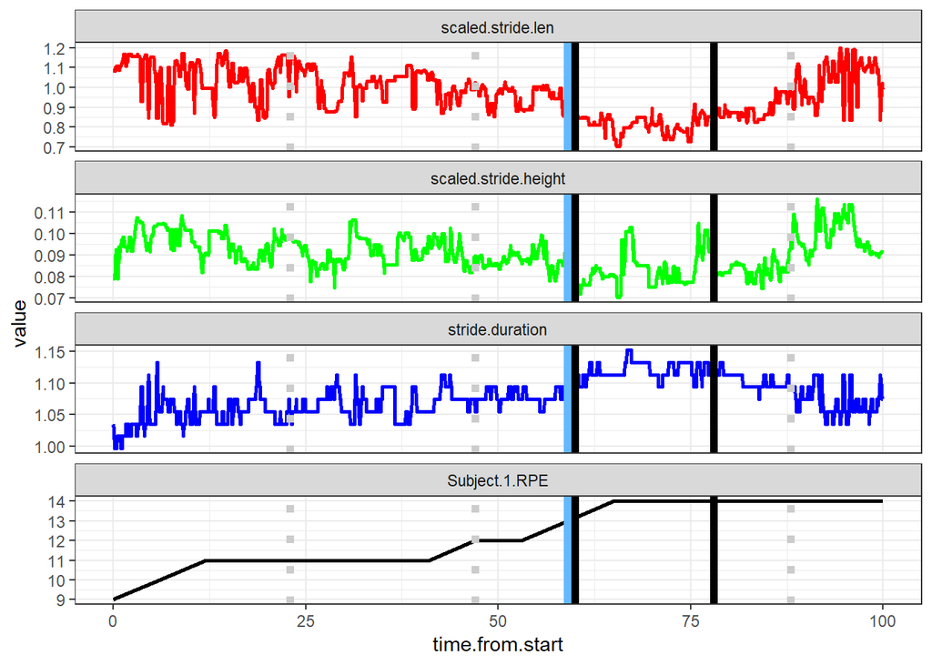

Based on the **ecp package, the number of changepoints for the the median filtered data for participant 1 is equal to: 2. These changepoints are located at: 60, 78. The threshold based changepoint in the subjective RPE is located at: 59.** In addition, **the number of changepoints based on the RPE values for this subject is equal to: 3. These changepoints are located at: 23, 47, 88.** The results from the analysis above can be found at: ChangepointsRPE.RData.

### P2

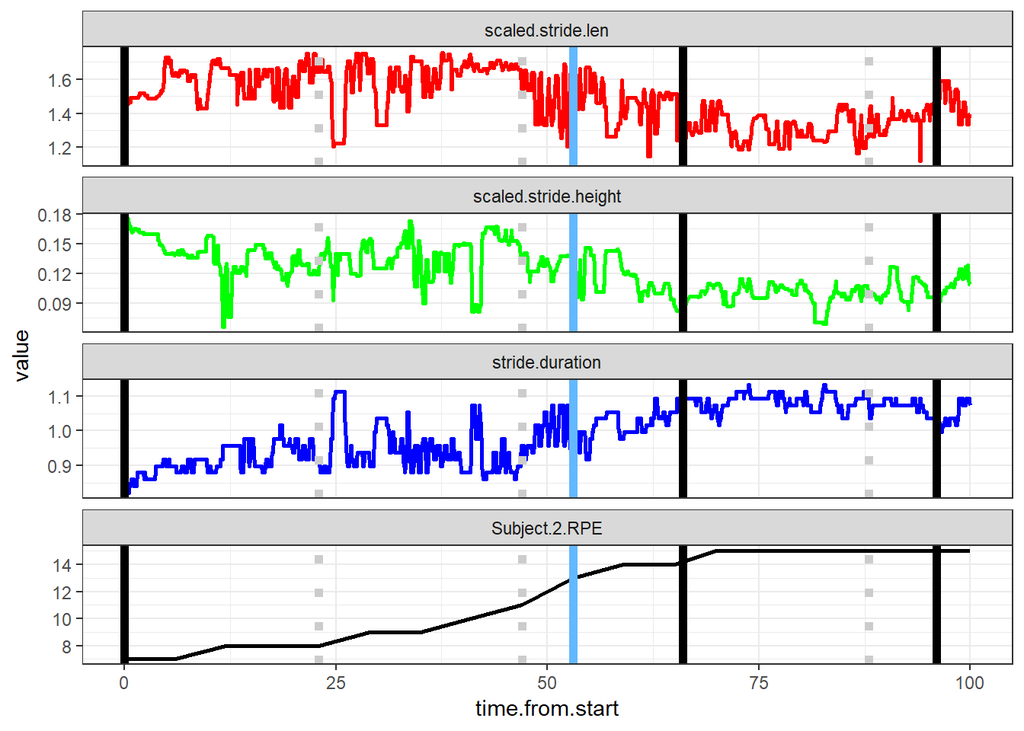

Based on the **ecp package, the number of changepoints for the the median filtered data for participant 2 is equal to: 3. These changepoints are located at: 0, 66, 96. The threshold based changepoint in the subjective RPE is located at: 53.** In addition, **the number of changepoints based on the RPE values for this subject is equal to: 3. These changepoints are located at: 23, 47, 88.** The results from the analysis above can be found at: ChangepointsRPE.RData.

### P3

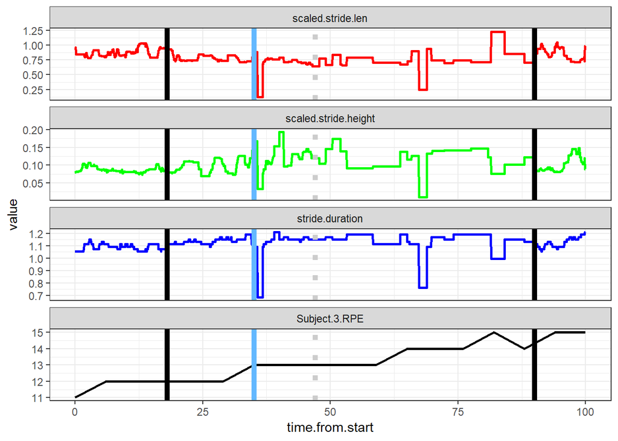

Based on the **ecp package, the number of changepoints for the the median filtered data for participant 3 is equal to: 2. These changepoints are located at: 18, 90. The threshold based changepoint in the subjective RPE is located at: 35.** In addition, **the number of changepoints based on the RPE values for this subject is equal to: 1. These changepoints are located at: 47.** The results from the analysis above can be found at: ChangepointsRPE.RData.

### P4

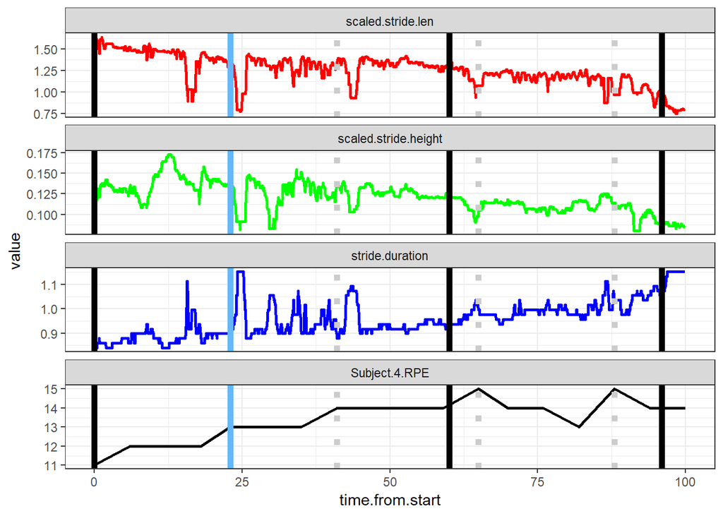

Based on the **ecp package, the number of changepoints for the the median filtered data for participant 4 is equal to: 3. These changepoints are located at: 0, 60, 96. The threshold based changepoint in the subjective RPE is located at: 23.** In addition, **the number of changepoints based on the RPE values for this subject is equal to: 3. These changepoints are located at: 41, 65, 88.** The results from the analysis above can be found at: ChangepointsRPE.RData.

### P5

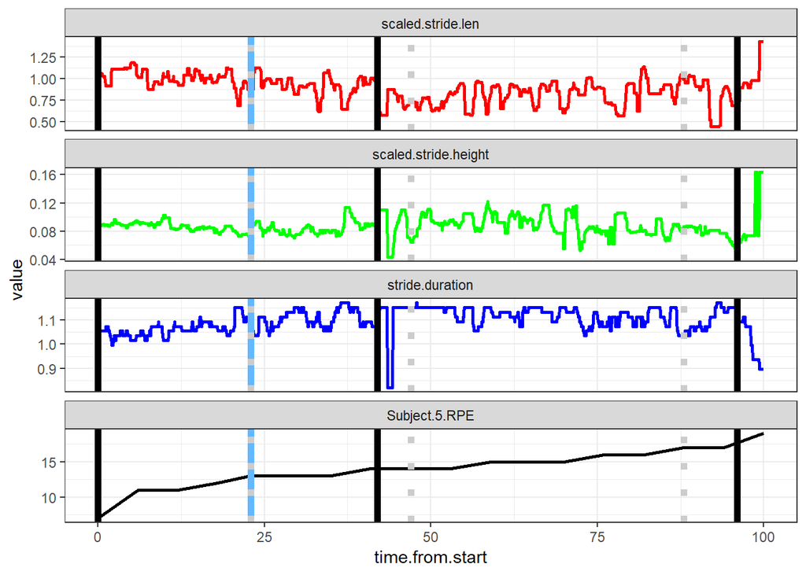

Based on the **ecp package, the number of changepoints for the the median filtered data for participant 5 is equal to: 3. These changepoints are located at: 0, 42, 96. The threshold based changepoint in the subjective RPE is located at: 23.** In addition, **the number of changepoints based on the RPE values for this subject is equal to: 3. These changepoints are located at: 23, 47, 88.** The results from the analysis above can be found at: ChangepointsRPE.RData.

### P6

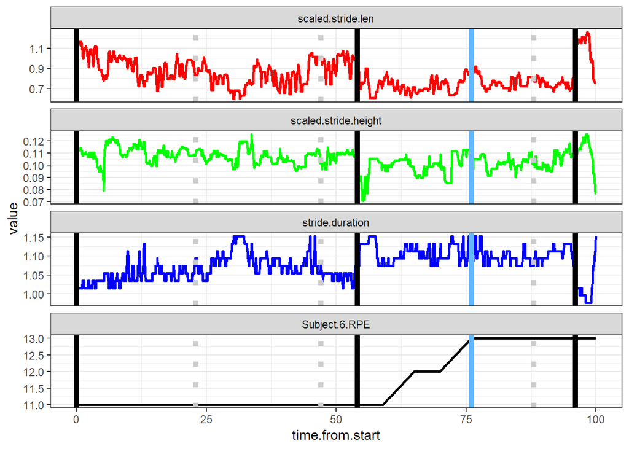

Based on the **ecp package, the number of changepoints for the the median filtered data for participant 6 is equal to: 3. These changepoints are located at: 0, 54, 96. The threshold based changepoint in the subjective RPE is located at: 76.** In addition, **the number of changepoints based on the RPE values for this subject is equal to: 3. These changepoints are located at: 23, 47, 88.** The results from the analysis above can be found at: ChangepointsRPE.RData.

### P7

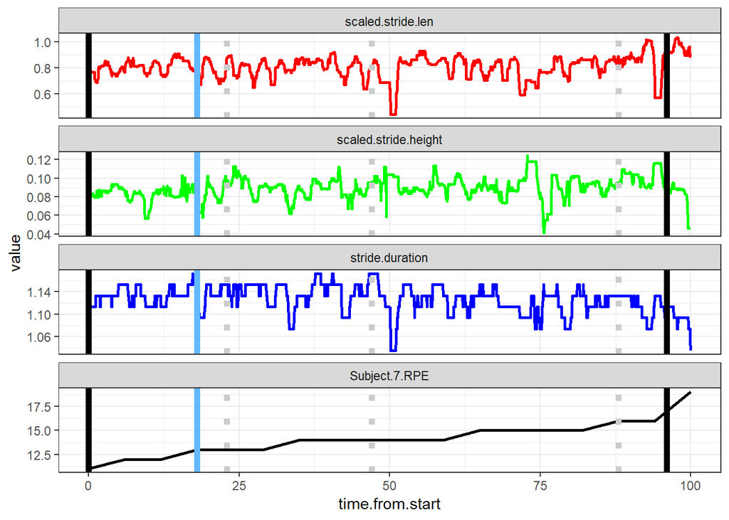

Based on the **ecp package, the number of changepoints for the the median filtered data for participant 7 is equal to: 2. These changepoints are located at: 0, 96. The threshold based changepoint in the subjective RPE is located at: 18.** In addition, **the number of changepoints based on the RPE values for this subject is equal to: 3. These changepoints are located at: 23, 47, 88.** The results from the analysis above can be found at: ChangepointsRPE.RData.

### P8

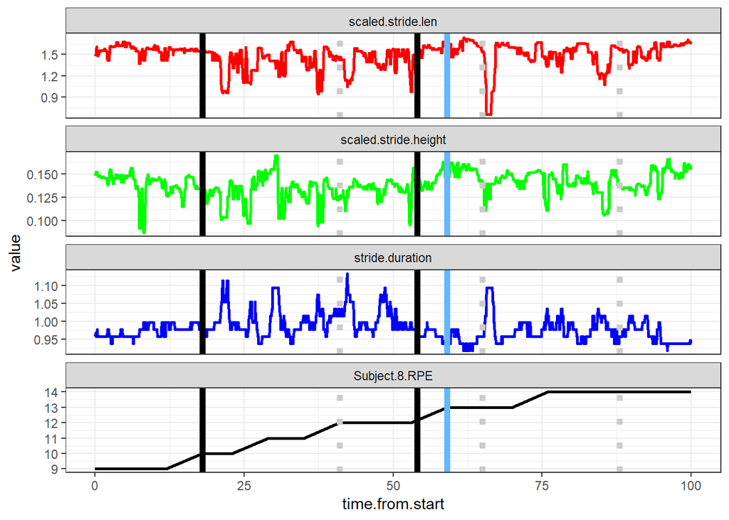

Based on the **ecp package, the number of changepoints for the the median filtered data for participant 8 is equal to: 2. These changepoints are located at: 18, 54. The threshold based changepoint in the subjective RPE is located at: 59.** In addition, **the number of changepoints based on the RPE values for this subject is equal to: 3. These changepoints are located at: 41, 65, 88.** The results from the analysis above can be found at: ChangepointsRPE.RData.

### P9

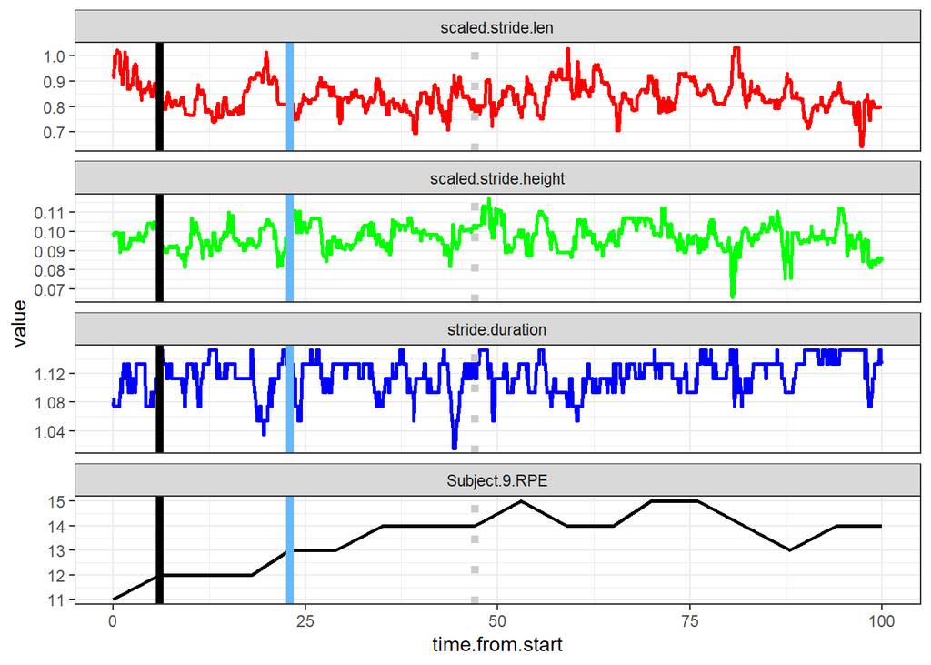

Based on the **ecp package, the number of changepoints for the the median filtered data for participant 9 is equal to: 1. These changepoints are located at: 6. The threshold based changepoint in the subjective RPE is located at: 23.** In addition, **the number of changepoints based on the RPE values for this subject is equal to: 1. These changepoints are located at: 47.** The results from the analysis above can be found at: ChangepointsRPE.RData.

### P10

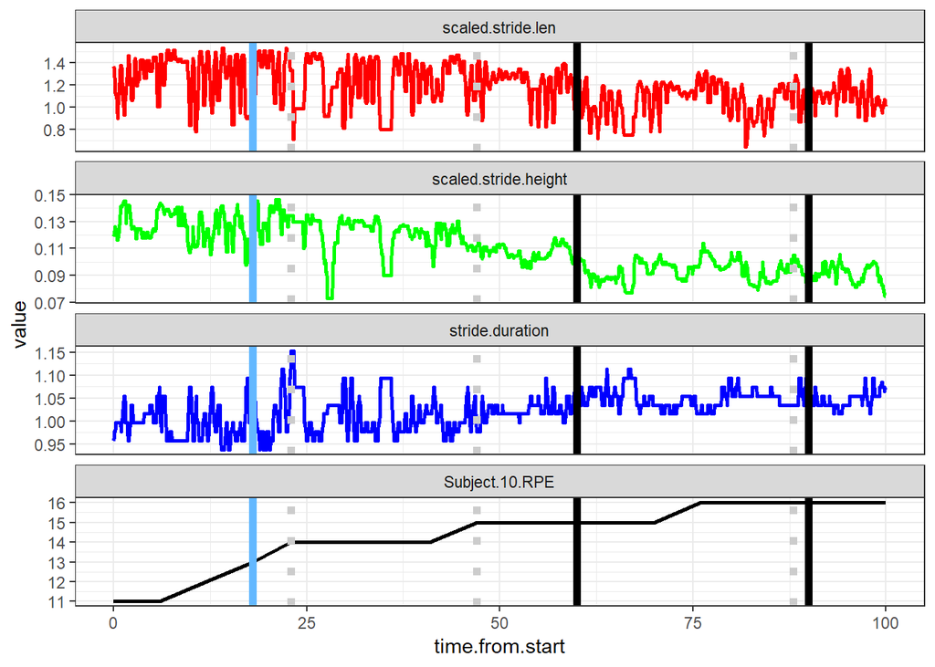

Based on the **ecp package, the number of changepoints for the the median filtered data for participant 10 is equal to: 2. These changepoints are located at: 60, 90. The threshold based changepoint in the subjective RPE is located at: 18.** In addition, **the number of changepoints based on the RPE values for this subject is equal to: 3. These changepoints are located at: 23, 47, 88.** The results from the analysis above can be found at: ChangepointsRPE.RData.

### P11

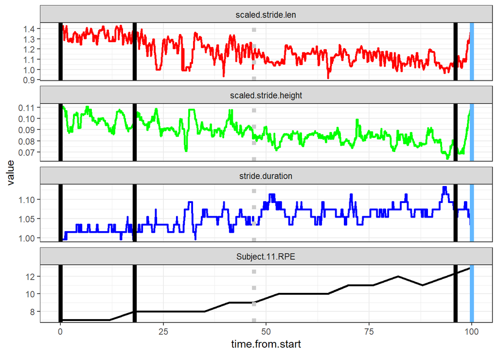

Based on the **ecp package, the number of changepoints for the the median filtered data for participant 11 is equal to: 3. These changepoints are located at: 0, 18, 96. The threshold based changepoint in the subjective RPE is located at: 100.** In addition, **the number of changepoints based on the RPE values for this subject is equal to: 1. These changepoints are located at: 47.** The results from the analysis above can be found at: ChangepointsRPE.RData.

### P12

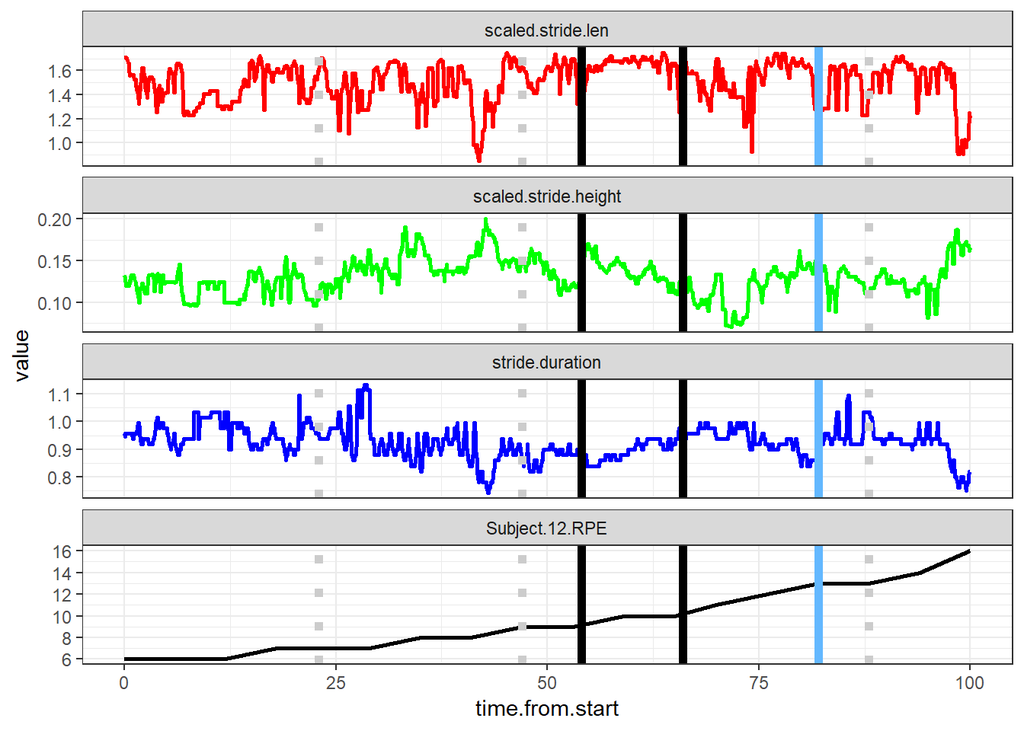

Based on the **ecp package, the number of changepoints for the the median filtered data for participant 12 is equal to: 2. These changepoints are located at: 54, 66. The threshold based changepoint in the subjective RPE is located at: 82.** In addition, **the number of changepoints based on the RPE values for this subject is equal to: 3. These changepoints are located at: 23, 47, 88.** The results from the analysis above can be found at: ChangepointsRPE.RData.

### P13

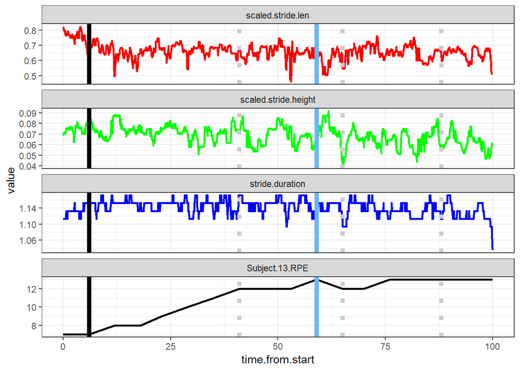

Based on the **ecp package, the number of changepoints for the the median filtered data for participant 13 is equal to: 1. These changepoints are located at: 6. The threshold based changepoint in the subjective RPE is located at: 59.** In addition, **the number of changepoints based on the RPE values for this subject is equal to: 3. These changepoints are located at: 41, 65, 88.** The results from the analysis above can be found at: ChangepointsRPE.RData.

### P14

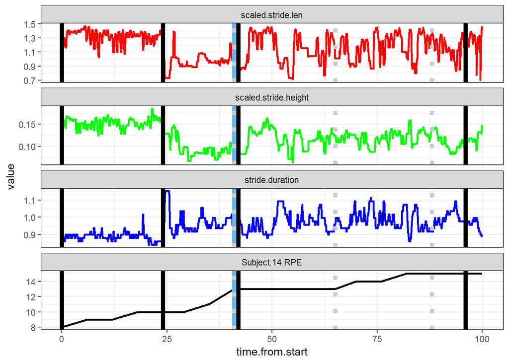

Based on the **ecp package, the number of changepoints for the the median filtered data for participant 14 is equal to: 4. These changepoints are located at: 0, 24, 42, 96. The threshold based changepoint in the subjective RPE is located at: 41.** In addition, **the number of changepoints based on the RPE values for this subject is equal to: 3. These changepoints are located at: 41, 65, 88.** The results from the analysis above can be found at: ChangepointsRPE.RData.

### P15

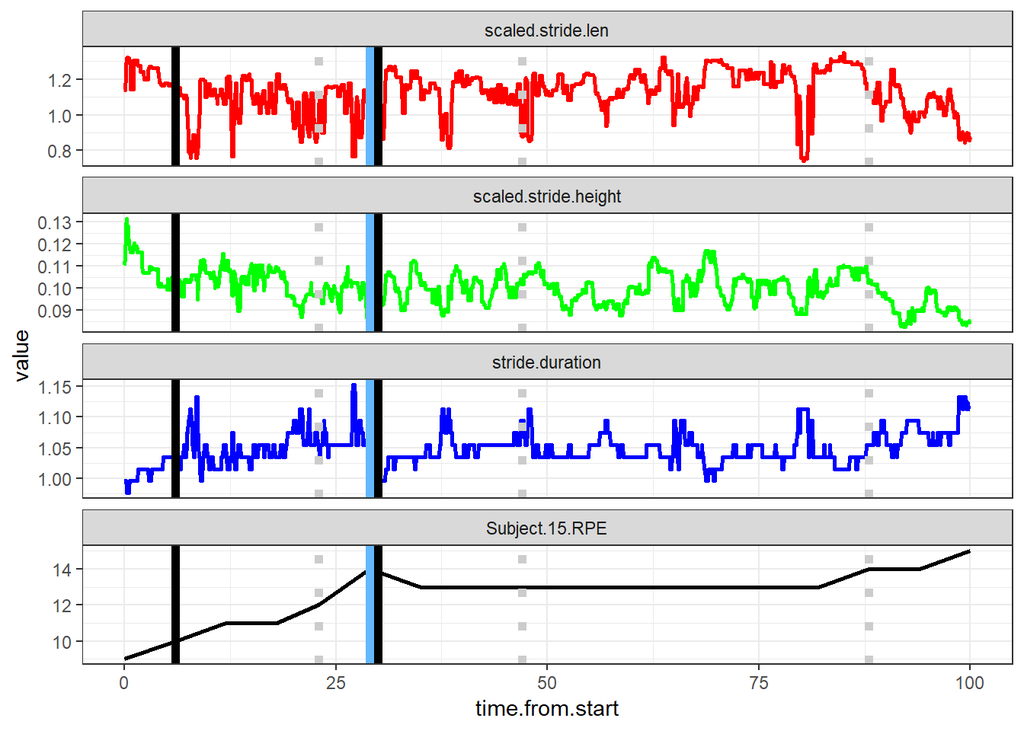

Based on the **ecp package, the number of changepoints for the the median filtered data for participant 15 is equal to: 2. These changepoints are located at: 6, 30. The threshold based changepoint in the subjective RPE is located at: 29.** In addition, **the number of changepoints based on the RPE values for this subject is equal to: 3. These changepoints are located at: 23, 47, 88.** The results from the analysis above can be found at: ChangepointsRPE.RData.

```r
save(changepoints_subj_ecp, changepoints_subj_thr,
     file = "./Data/RGenerated/ChangepointsRPE.RData")
```

## 4.2 Plots with the CUSUM of the Median Filtered Data and the ECP-CUSUM Changepoints

In this section, we perform the following tasks:

1. EDA, where we overlay the subjective ratings with the **CUSUM changepoints**;
2. A threshold based comparison, where we use $\small RPE \ge 13$ to identify when a participant becomes fatigued and we compare that to the changepoints detected by the hybrid CUSUM-EPC approach; and
3. Utilize the [e.divisive() from the ecp package](https://cran.r-project.org/web/packages/ecp/vignettes/ecp.pdf) to obtain the changepoints for the Borg Ratings. Note that this function is the univariate approach for the multiple changepoint method examined in Section 4.1.

```r
RatingThresh <- 13  # based on Maman et al. 2017
RPE = read.csv("https://raw.githubusercontent.com/fmegahed/fatigue-changepoint/master/Data/Raw/RPE.csv") # to read subjective rating of RPE data from GitHub'
colnames(RPE)[1] <- "time.from.start"
df_RPE_transformed <- melt(RPE,
                           id.vars = "time.from.start",
                           measure.vars = colnames(RPE)[2:16])
df_RPE_transformed[,2] <- paste0(df_RPE_transformed[,2],".RPE")
# to load previously generated data and changepoints
load(file = "./Data/RGenerated/NormCusumData.RData")
load(file = "./Data/RGenerated/ECPChangePointsCUSUM.RData")
changepoints_subj_ecp <- list()
changepoints_subj_thr <- list()

for (i in 1:15) {
  correct_subject_rows <- which(df_RPE_transformed[,2]==paste0("Subject.",i,".RPE"))
  dataholder <- df_RPE_transformed[correct_subject_rows,]


  # -------- Calculation of Fatigue based on RPE>= 13 -----------------
  fatigue_from_RPE_threshold <- which(RPE[,i+1]>=RatingThresh) %>%
                              min() # returns window number
  changepoints_subj_thr[[i]] <- RPE[fatigue_from_RPE_threshold,1]
  df_RPE<-data.frame(d1=RPE[1],t1=RPE[i+1]) %>% na.omit() # to make dataframe of subjective ratings for ggplot

  #------- Estimation of Fatigue Changepoints based on ECP of the RPE Data --
  y <- e.divisive(df_RPE,min.size = 2)$estimates
  fatigue_from_ecp_changepoint = y[2:(length(y)-1)] # removing the first and last points as trivials changepoints
  changepoints_subj_ecp[[i]] <- df_RPE[fatigue_from_ecp_changepoint,1]

  cat('###',paste0("P", i), "{-}",'\n')
  df_transformed <- melt(get(paste0("subject",i,"_cusum_norm")),
                       id.vars = "time.from.start",
                       measure.vars=c("scaled.stride.len",
                                      "scaled.stride.height",
                                      "stride.duration"
                                      )
                         )
  df_transformed <- rbind(df_transformed,df_RPE_transformed[correct_subject_rows,])

  assign(paste0("g",i),
        ggplot(data = df_transformed,
               aes(x=time.from.start, y=value, colour = variable)) +
          geom_line(size=1) +
          theme_bw() +
          scale_colour_manual(values = c("red", "green", "blue","black","grey40")) +
          facet_wrap(~variable,nrow=5, scales = "free_y") +
          # labs(title = paste("A paneled time-series plot for Participant",i)) +
          geom_vline(xintercept= changepoints_cusum[[i]],
                     show.legend = T, size=2) +
          geom_vline(xintercept= changepoints_subj_thr[[i]],
                     linetype="solid", color="steelblue1",
                     show.legend = T, size=2) +
          geom_vline(xintercept= changepoints_subj_ecp[[i]],
                     linetype="dotted", color="gray80",
                     show.legend =T, size=2) +
          theme(legend.position="none",
                 plot.title = element_text(hjust = 0.5))
      )

      print(get(paste0("g",i)))

  cat('\n \n')

  cat(paste0('<source> <p> In the above figure, the colored vertical lines correspond to the following.  First, the <b> black  lines are used to denote the changepoints based on the non-parameteric, multivariate, ECP approach on the CUSUMS of the Kinematic Features. </b> These changepoints are what we obtained in Section 4.1.3. Second, the <font color= #63B8FF> <b>steelblue line  correspond to the time from start in seconds, when the subject has a RPE that equals or exceeds 13. </b> </font> Note that we only indicate the first occurence when the RPE>=13 on the graphs. Third, the <b> <font color=#CCCCCC> gray lines  denote the univariate, nonparametric changepoints obtained from applying the e.divisive() on the RPE values from the subject. </font> </b>',
'. </font> </b> \n \n'))

  cat(paste0('<source> <p> Based on the <b>ecp package, the number of changepoints for the cusums of the median filtered data for participant ', i,
             ' is equal to: ',
             length(changepoints_cusum[[i]]),
             '. These changepoints are located at: ',
             paste(round(changepoints_cusum[[i]]), collapse = ", "),
             '.  <font color= #63B8FF> The threshold based changepoint in the subjective RPE is located at: ',
             paste(changepoints_subj_thr[[i]]),
             '. </font> </b> In addition, <b> <font color=#CCCCCC> the number of changepoints based on the RPE values for this subject is equal to: ',
             length(changepoints_subj_ecp[[i]]),
             ". These changepoints are located at: ",
             paste(changepoints_subj_ecp[[i]], collapse = ", "),
             '. </b> </font> Note that the results from the analysis above can be found at: <a href="https://github.com/fmegahed/fatigue-changepoint/blob/master/Data/RGenerated/ChangepointsRPE.RData">ChangepointsRPE.RData</a>. This is the same link as that provided in the previous section since the RPEresults are identical. The change here was overlaying the RPE results with the CUSUM of the median filtered data and their corresponding changepoints from the ECP package (instead of directly with the median filtered data and their changepoints [also from the ECP package]). </p> </source>')
      )


  cat('\n \n')

  }
```

### P1

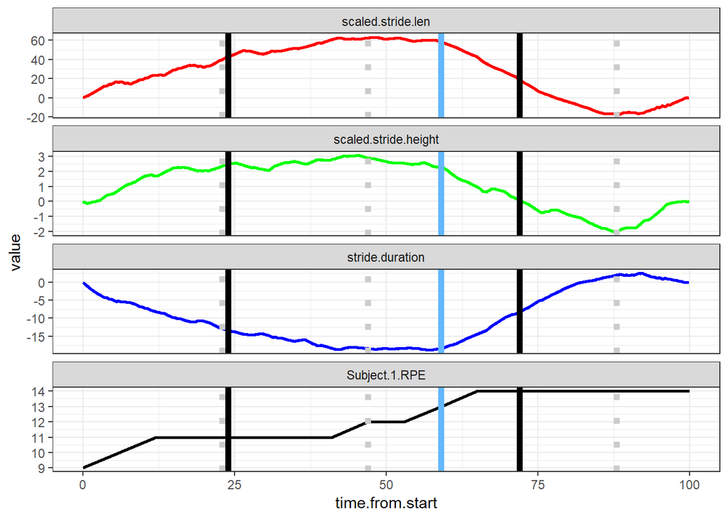

In the above figure, the colored vertical lines correspond to the following. First, the **black lines are used to denote the changepoints based on the non-parameteric, multivariate, ECP approach on the CUSUMS of the Kinematic Features.** These changepoints are what we obtained in Section 4.1.3. Second, the **steelblue line correspond to the time from start in seconds, when the subject has a RPE that equals or exceeds 13.** Note that we only indicate the first occurence when the RPE>=13 on the graphs. Third, the **gray lines denote the univariate, nonparametric changepoints obtained from applying the e.divisive() on the RPE values from the subject.** .

Based on the **ecp package, the number of changepoints for the cusums of the median filtered data for participant 1 is equal to: 2. These changepoints are located at: 24, 72. The threshold based changepoint in the subjective RPE is located at: 59.** In addition, **the number of changepoints based on the RPE values for this subject is equal to: 3. These changepoints are located at: 23, 47, 88.** Note that the results from the analysis above can be found at: ChangepointsRPE.RData. This is the same link as that provided in the previous section since the RPEresults are identical. The change here was overlaying the RPE results with the CUSUM of the median filtered data and their corresponding changepoints from the ECP package (instead of directly with the median filtered data and their changepoints [also from the ECP package]).

### P2

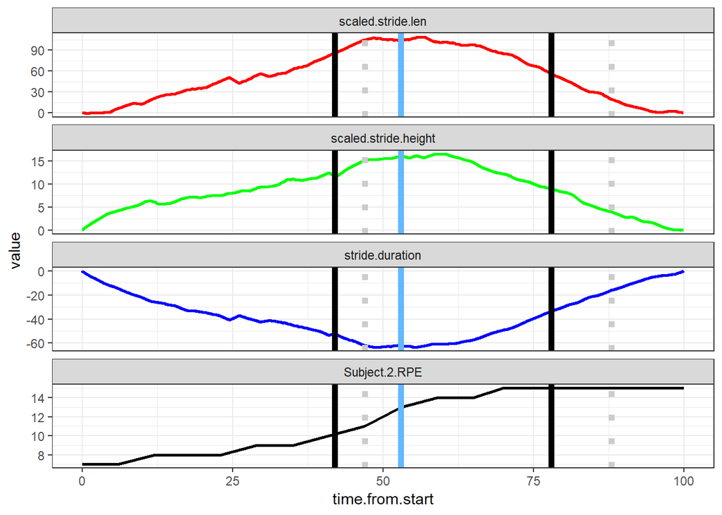

In the above figure, the colored vertical lines correspond to the following. First, the **black lines are used to denote the changepoints based on the non-parameteric, multivariate, ECP approach on the CUSUMS of the Kinematic Features.** These changepoints are what we obtained in Section 4.1.3. Second, the **steelblue line correspond to the time from start in seconds, when the subject has a RPE that equals or exceeds 13.** Note that we only indicate the first occurence when the RPE>=13 on the graphs. Third, the **gray lines denote the univariate, nonparametric changepoints obtained from applying the e.divisive() on the RPE values from the subject.** .

Based on the **ecp package, the number of changepoints for the cusums of the median filtered data for participant 2 is equal to: 2. These changepoints are located at: 42, 78. The threshold based changepoint in the subjective RPE is located at: 53.** In addition, **the number of changepoints based on the RPE values for this subject is equal to: 2. These changepoints are located at: 47, 88.** Note that the results from the analysis above can be found at: ChangepointsRPE.RData. This is the same link as that provided in the previous section since the RPEresults are identical. The change here was overlaying the RPE results with the CUSUM of the median filtered data and their corresponding changepoints from the ECP package (instead of directly with the median filtered data and their changepoints [also from the ECP package]).

### P3

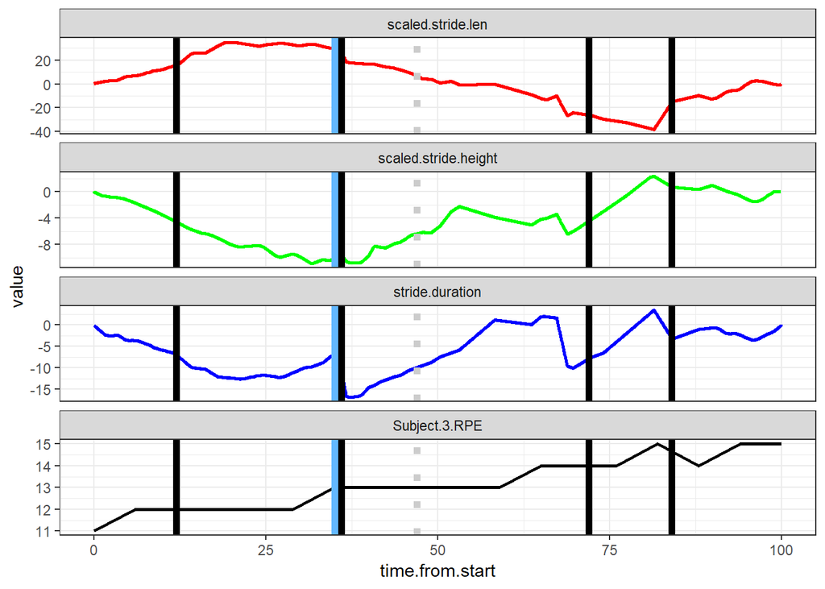

In the above figure, the colored vertical lines correspond to the following. First, the **black lines are used to denote the changepoints based on the non-parameteric, multivariate, ECP approach on the CUSUMS of the Kinematic Features.** These changepoints are what we obtained in Section 4.1.3. Second, the **steelblue line correspond to the time from start in seconds, when the subject has a RPE that equals or exceeds 13.** Note that we only indicate the first occurence when the RPE>=13 on the graphs. Third, the **gray lines denote the univariate, nonparametric changepoints obtained from applying the e.divisive() on the RPE values from the subject.** .

Based on the **ecp package, the number of changepoints for the cusums of the median filtered data for participant 3 is equal to: 4. These changepoints are located at: 12, 36, 72, 84. The threshold based changepoint in the subjective RPE is located at: 35.** In addition, **the number of changepoints based on the RPE values for this subject is equal to: 1. These changepoints are located at: 47.** Note that the results from the analysis above can be found at: ChangepointsRPE.RData. This is the same link as that provided in the previous section since the RPEresults are identical. The change here was overlaying the RPE results with the CUSUM of the median filtered data and their corresponding changepoints from the ECP package (instead of directly with the median filtered data and their changepoints [also from the ECP package]).

### P4

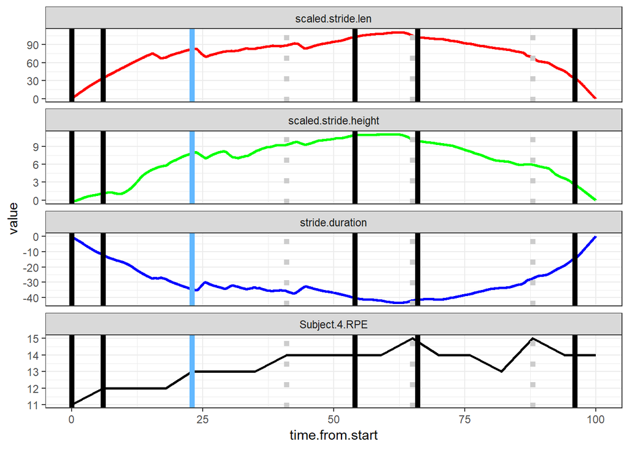

In the above figure, the colored vertical lines correspond to the following. First, the **black lines are used to denote the changepoints based on the non-parameteric, multivariate, ECP approach on the CUSUMS of the Kinematic Features.** These changepoints are what we obtained in Section 4.1.3. Second, the **steelblue line correspond to the time from start in seconds, when the subject has a RPE that equals or exceeds 13.** Note that we only indicate the first occurence when the RPE>=13 on the graphs. Third, the **gray lines denote the univariate, nonparametric changepoints obtained from applying the e.divisive() on the RPE values from the subject.** .

Based on the **ecp package, the number of changepoints for the cusums of the median filtered data for participant 4 is equal to: 5. These changepoints are located at: 0, 6, 54, 66, 96. The threshold based changepoint in the subjective RPE is located at: 23.** In addition, **the number of changepoints based on the RPE values for this subject is equal to: 3. These changepoints are located at: 41, 65, 88.** Note that the results from the analysis above can be found at: ChangepointsRPE.RData. This is the same link as that provided in the previous section since the RPEresults are identical. The change here was overlaying the RPE results with the CUSUM of the median filtered data and their corresponding changepoints from the ECP package (instead of directly with the median filtered data and their changepoints [also from the ECP package]).

### P5

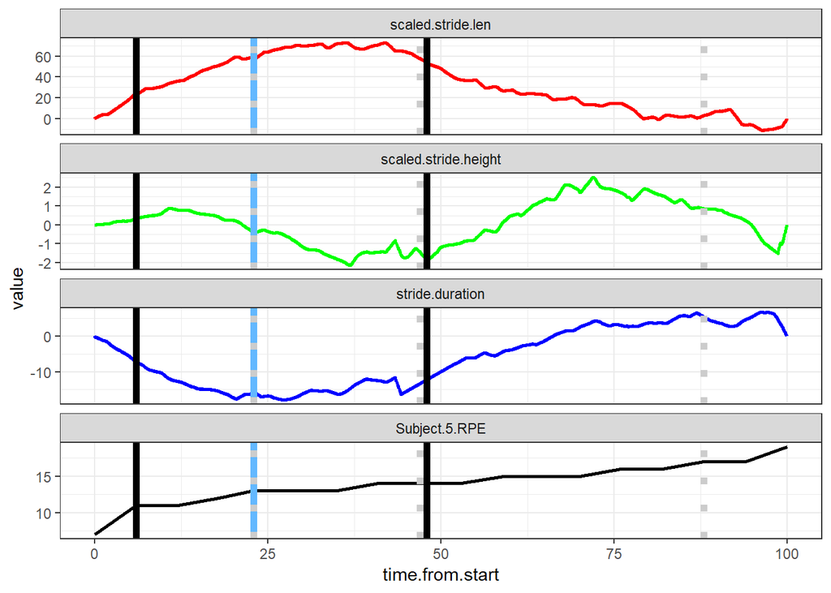

In the above figure, the colored vertical lines correspond to the following. First, the **black lines are used to denote the changepoints based on the non-parameteric, multivariate, ECP approach on the CUSUMS of the Kinematic Features.** These changepoints are what we obtained in Section 4.1.3. Second, the **steelblue line correspond to the time from start in seconds, when the subject has a RPE that equals or exceeds 13.** Note that we only indicate the first occurence when the RPE>=13 on the graphs. Third, the **gray lines denote the univariate, nonparametric changepoints obtained from applying the e.divisive() on the RPE values from the subject.** .

Based on the **ecp package, the number of changepoints for the cusums of the median filtered data for participant 5 is equal to: 2. These changepoints are located at: 6, 48. The threshold based changepoint in the subjective RPE is located at: 23.** In addition, **the number of changepoints based on the RPE values for this subject is equal to: 3. These changepoints are located at: 23, 47, 88.** Note that the results from the analysis above can be found at: ChangepointsRPE.RData. This is the same link as that provided in the previous section since the RPEresults are identical. The change here was overlaying the RPE results with the CUSUM of the median filtered data and their corresponding changepoints from the ECP package (instead of directly with the median filtered data and their changepoints [also from the ECP package]).

### P6

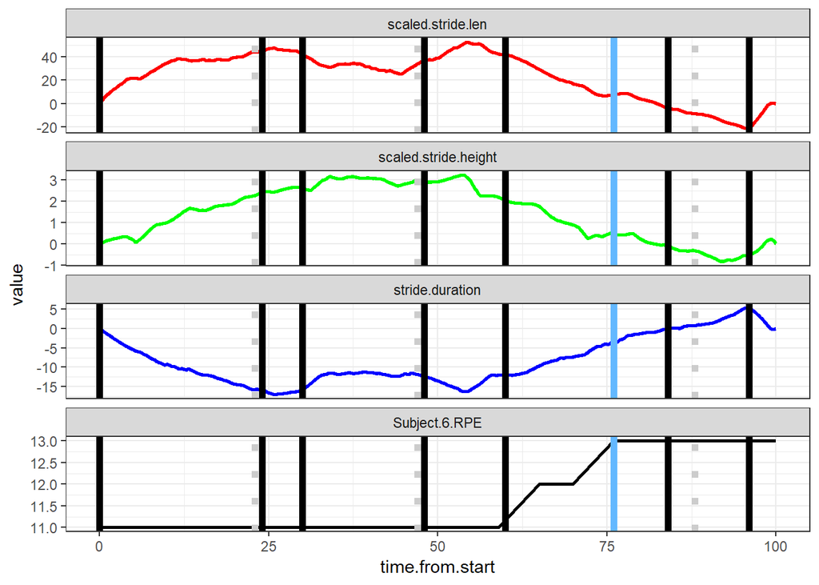

In the above figure, the colored vertical lines correspond to the following. First, the **black lines are used to denote the changepoints based on the non-parameteric, multivariate, ECP approach on the CUSUMS of the Kinematic Features.** These changepoints are what we obtained in Section 4.1.3. Second, the **steelblue line correspond to the time from start in seconds, when the subject has a RPE that equals or exceeds 13.** Note that we only indicate the first occurence when the RPE>=13 on the graphs. Third, the **gray lines denote the univariate, nonparametric changepoints obtained from applying the e.divisive() on the RPE values from the subject.** .

Based on the **ecp package, the number of changepoints for the cusums of the median filtered data for participant 6 is equal to: 7. These changepoints are located at: 0, 24, 30, 48, 60, 84, 96. The threshold based changepoint in the subjective RPE is located at: 76.** In addition, **the number of changepoints based on the RPE values for this subject is equal to: 3. These changepoints are located at: 23, 47, 88.** Note that the results from the analysis above can be found at: ChangepointsRPE.RData. This is the same link as that provided in the previous section since the RPEresults are identical. The change here was overlaying the RPE results with the CUSUM of the median filtered data and their corresponding changepoints from the ECP package (instead of directly with the median filtered data and their changepoints [also from the ECP package]).

### P7

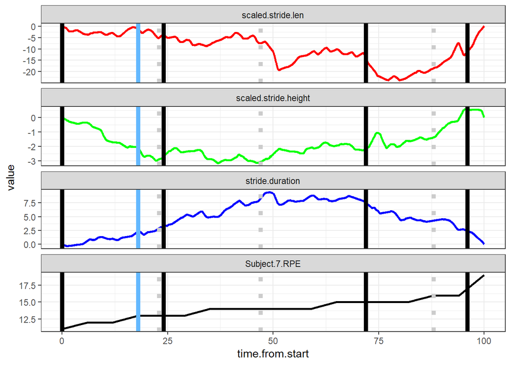

In the above figure, the colored vertical lines correspond to the following. First, the **black lines are used to denote the changepoints based on the non-parameteric, multivariate, ECP approach on the CUSUMS of the Kinematic Features.** These changepoints are what we obtained in Section 4.1.3. Second, the **steelblue line correspond to the time from start in seconds, when the subject has a RPE that equals or exceeds 13.** Note that we only indicate the first occurence when the RPE>=13 on the graphs. Third, the **gray lines denote the univariate, nonparametric changepoints obtained from applying the e.divisive() on the RPE values from the subject.** .

Based on the **ecp package, the number of changepoints for the cusums of the median filtered data for participant 7 is equal to: 4. These changepoints are located at: 0, 24, 72, 96. The threshold based changepoint in the subjective RPE is located at: 18.** In addition, **the number of changepoints based on the RPE values for this subject is equal to: 3. These changepoints are located at: 23, 47, 88.** Note that the results from the analysis above can be found at: ChangepointsRPE.RData. This is the same link as that provided in the previous section since the RPEresults are identical. The change here was overlaying the RPE results with the CUSUM of the median filtered data and their corresponding changepoints from the ECP package (instead of directly with the median filtered data and their changepoints [also from the ECP package]).

### P8

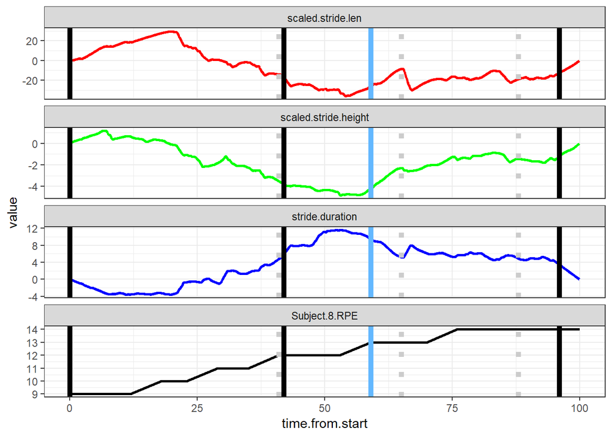

In the above figure, the colored vertical lines correspond to the following. First, the **black lines are used to denote the changepoints based on the non-parameteric, multivariate, ECP approach on the CUSUMS of the Kinematic Features.** These changepoints are what we obtained in Section 4.1.3. Second, the **steelblue line correspond to the time from start in seconds, when the subject has a RPE that equals or exceeds 13.** Note that we only indicate the first occurence when the RPE>=13 on the graphs. Third, the **gray lines denote the univariate, nonparametric changepoints obtained from applying the e.divisive() on the RPE values from the subject.** .

Based on the **ecp package, the number of changepoints for the cusums of the median filtered data for participant 8 is equal to: 3. These changepoints are located at: 0, 42, 96. The threshold based changepoint in the subjective RPE is located at: 59.** In addition, **the number of changepoints based on the RPE values for this subject is equal to: 3. These changepoints are located at: 41, 65, 88.** Note that the results from the analysis above can be found at: ChangepointsRPE.RData. This is the same link as that provided in the previous section since the RPEresults are identical. The change here was overlaying the RPE results with the CUSUM of the median filtered data and their corresponding changepoints from the ECP package (instead of directly with the median filtered data and their changepoints [also from the ECP package]).

### P9

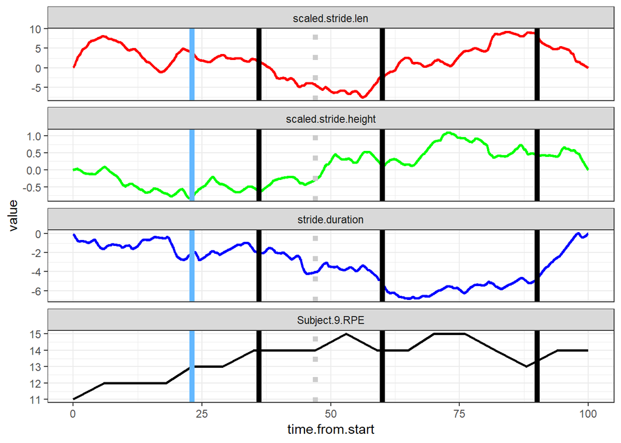

In the above figure, the colored vertical lines correspond to the following. First, the **black lines are used to denote the changepoints based on the non-parameteric, multivariate, ECP approach on the CUSUMS of the Kinematic Features.** These changepoints are what we obtained in Section 4.1.3. Second, the **steelblue line correspond to the time from start in seconds, when the subject has a RPE that equals or exceeds 13.** Note that we only indicate the first occurence when the RPE>=13 on the graphs. Third, the **gray lines denote the univariate, nonparametric changepoints obtained from applying the e.divisive() on the RPE values from the subject.** .

Based on the **ecp package, the number of changepoints for the cusums of the median filtered data for participant 9 is equal to: 3. These changepoints are located at: 36, 60, 90. The threshold based changepoint in the subjective RPE is located at: 23.** In addition, **the number of changepoints based on the RPE values for this subject is equal to: 1. These changepoints are located at: 47.** Note that the results from the analysis above can be found at: ChangepointsRPE.RData. This is the same link as that provided in the previous section since the RPEresults are identical. The change here was overlaying the RPE results with the CUSUM of the median filtered data and their corresponding changepoints from the ECP package (instead of directly with the median filtered data and their changepoints [also from the ECP package]).

### P10

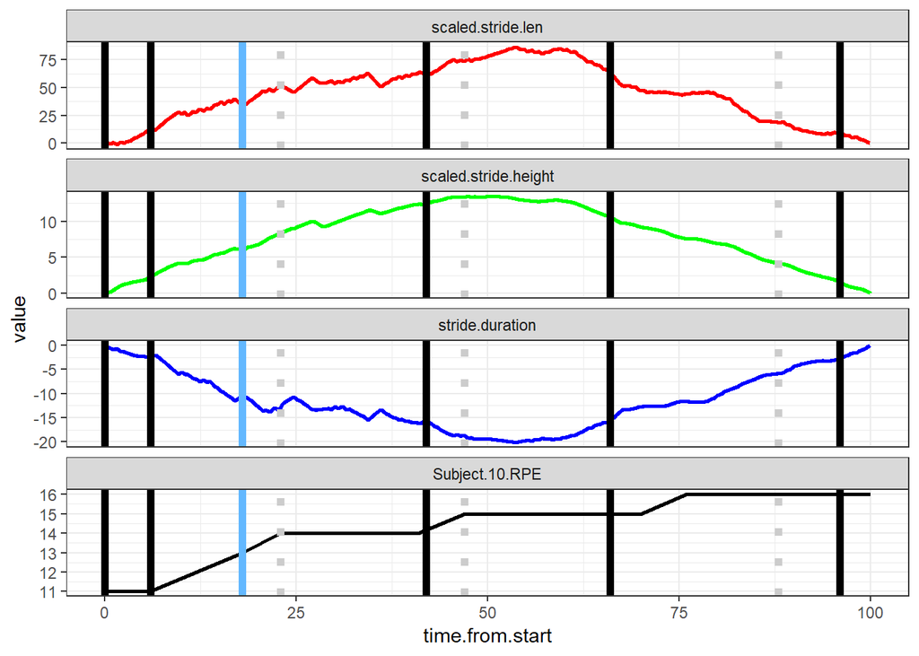

In the above figure, the colored vertical lines correspond to the following. First, the **black lines are used to denote the changepoints based on the non-parameteric, multivariate, ECP approach on the CUSUMS of the Kinematic Features.** These changepoints are what we obtained in Section 4.1.3. Second, the **steelblue line correspond to the time from start in seconds, when the subject has a RPE that equals or exceeds 13.** Note that we only indicate the first occurence when the RPE>=13 on the graphs. Third, the **gray lines denote the univariate, nonparametric changepoints obtained from applying the e.divisive() on the RPE values from the subject.** .

Based on the **ecp package, the number of changepoints for the cusums of the median filtered data for participant 10 is equal to: 5. These changepoints are located at: 0, 6, 42, 66, 96. The threshold based changepoint in the subjective RPE is located at: 18.** In addition, **the number of changepoints based on the RPE values for this subject is equal to: 3. These changepoints are located at: 23, 47, 88.** Note that the results from the analysis above can be found at: ChangepointsRPE.RData. This is the same link as that provided in the previous section since the RPEresults are identical. The change here was overlaying the RPE results with the CUSUM of the median filtered data and their corresponding changepoints from the ECP package (instead of directly with the median filtered data and their changepoints [also from the ECP package]).

### P11

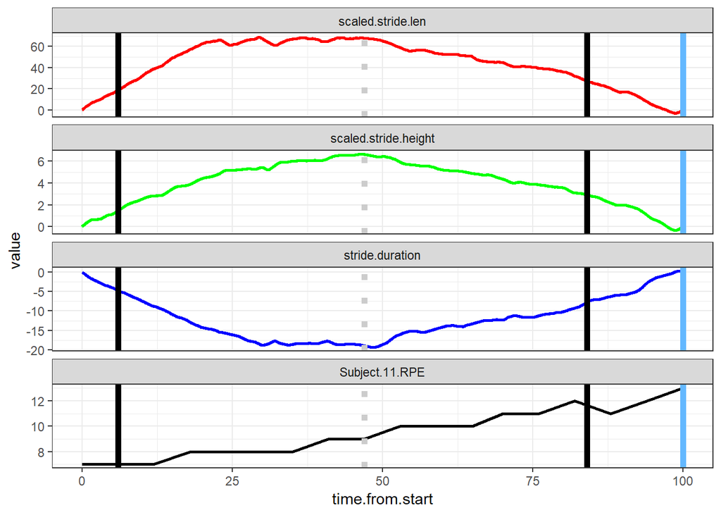

In the above figure, the colored vertical lines correspond to the following. First, the **black lines are used to denote the changepoints based on the non-parameteric, multivariate, ECP approach on the CUSUMS of the Kinematic Features.** These changepoints are what we obtained in Section 4.1.3. Second, the **steelblue line correspond to the time from start in seconds, when the subject has a RPE that equals or exceeds 13.** Note that we only indicate the first occurence when the RPE>=13 on the graphs. Third, the **gray lines denote the univariate, nonparametric changepoints obtained from applying the e.divisive() on the RPE values from the subject.** .

Based on the **ecp package, the number of changepoints for the cusums of the median filtered data for participant 11 is equal to: 2. These changepoints are located at: 6, 84. The threshold based changepoint in the subjective RPE is located at: 100.** In addition, **the number of changepoints based on the RPE values for this subject is equal to: 1. These changepoints are located at: 47.** Note that the results from the analysis above can be found at: ChangepointsRPE.RData. This is the same link as that provided in the previous section since the RPEresults are identical. The change here was overlaying the RPE results with the CUSUM of the median filtered data and their corresponding changepoints from the ECP package (instead of directly with the median filtered data and their changepoints [also from the ECP package]).

### P12

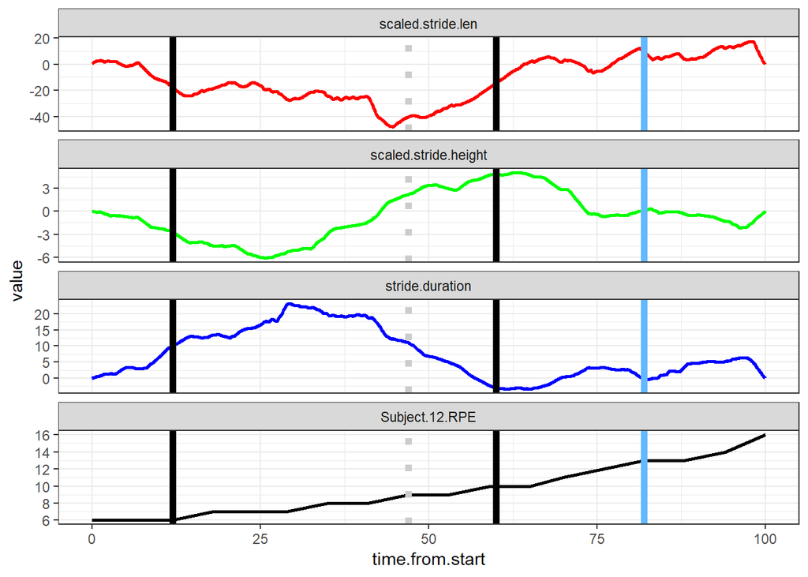

In the above figure, the colored vertical lines correspond to the following. First, the **black lines are used to denote the changepoints based on the non-parameteric, multivariate, ECP approach on the CUSUMS of the Kinematic Features.** These changepoints are what we obtained in Section 4.1.3. Second, the **steelblue line correspond to the time from start in seconds, when the subject has a RPE that equals or exceeds 13.** Note that we only indicate the first occurence when the RPE>=13 on the graphs. Third, the **gray lines denote the univariate, nonparametric changepoints obtained from applying the e.divisive() on the RPE values from the subject.** .

Based on the **ecp package, the number of changepoints for the cusums of the median filtered data for participant 12 is equal to: 2. These changepoints are located at: 12, 60. The threshold based changepoint in the subjective RPE is located at: 82.** In addition, **the number of changepoints based on the RPE values for this subject is equal to: 1. These changepoints are located at: 47.** Note that the results from the analysis above can be found at: ChangepointsRPE.RData. This is the same link as that provided in the previous section since the RPEresults are identical. The change here was overlaying the RPE results with the CUSUM of the median filtered data and their corresponding changepoints from the ECP package (instead of directly with the median filtered data and their changepoints [also from the ECP package]).

### P13

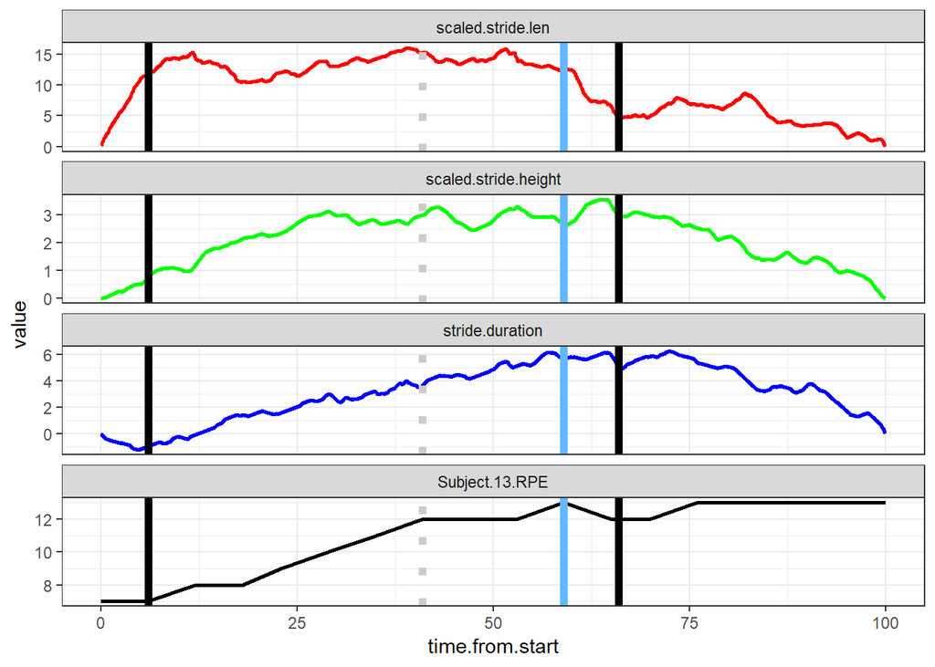

In the above figure, the colored vertical lines correspond to the following. First, the **black lines are used to denote the changepoints based on the non-parameteric, multivariate, ECP approach on the CUSUMS of the Kinematic Features.** These changepoints are what we obtained in Section 4.1.3. Second, the **steelblue line correspond to the time from start in seconds, when the subject has a RPE that equals or exceeds 13.** Note that we only indicate the first occurence when the RPE>=13 on the graphs. Third, the **gray lines denote the univariate, nonparametric changepoints obtained from applying the e.divisive() on the RPE values from the subject.** .

Based on the **ecp package, the number of changepoints for the cusums of the median filtered data for participant 13 is equal to: 2. These changepoints are located at: 6, 66. The threshold based changepoint in the subjective RPE is located at: 59.** In addition, **the number of changepoints based on the RPE values for this subject is equal to: 1. These changepoints are located at: 41.** Note that the results from the analysis above can be found at: ChangepointsRPE.RData. This is the same link as that provided in the previous section since the RPEresults are identical. The change here was overlaying the RPE results with the CUSUM of the median filtered data and their corresponding changepoints from the ECP package (instead of directly with the median filtered data and their changepoints [also from the ECP package]).

### P14

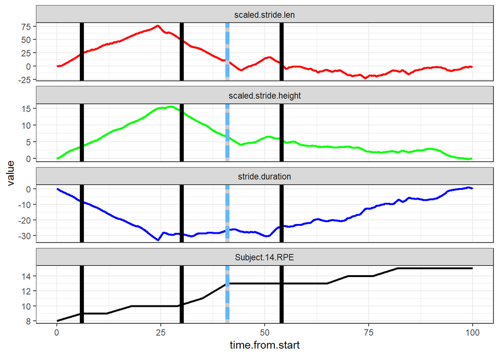

In the above figure, the colored vertical lines correspond to the following. First, the **black lines are used to denote the changepoints based on the non-parameteric, multivariate, ECP approach on the CUSUMS of the Kinematic Features.** These changepoints are what we obtained in Section 4.1.3. Second, the **steelblue line correspond to the time from start in seconds, when the subject has a RPE that equals or exceeds 13.** Note that we only indicate the first occurence when the RPE>=13 on the graphs. Third, the **gray lines denote the univariate, nonparametric changepoints obtained from applying the e.divisive() on the RPE values from the subject.** .

Based on the **ecp package, the number of changepoints for the cusums of the median filtered data for participant 14 is equal to: 3. These changepoints are located at: 6, 30, 54. The threshold based changepoint in the subjective RPE is located at: 41.** In addition, **the number of changepoints based on the RPE values for this subject is equal to: 1. These changepoints are located at: 41.** Note that the results from the analysis above can be found at: ChangepointsRPE.RData. This is the same link as that provided in the previous section since the RPEresults are identical. The change here was overlaying the RPE results with the CUSUM of the median filtered data and their corresponding changepoints from the ECP package (instead of directly with the median filtered data and their changepoints [also from the ECP package]).

### P15

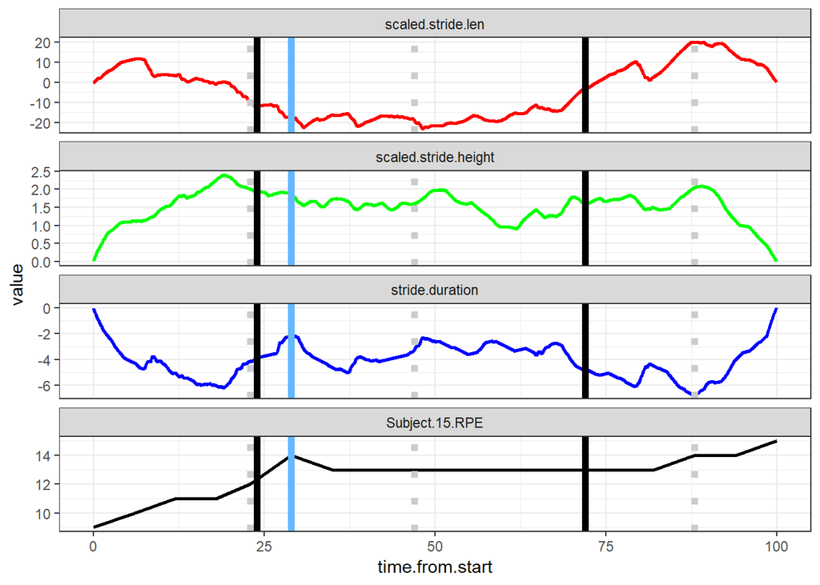

In the above figure, the colored vertical lines correspond to the following. First, the **black lines are used to denote the changepoints based on the non-parameteric, multivariate, ECP approach on the CUSUMS of the Kinematic Features.** These changepoints are what we obtained in Section 4.1.3. Second, the **steelblue line correspond to the time from start in seconds, when the subject has a RPE that equals or exceeds 13.** Note that we only indicate the first occurence when the RPE>=13 on the graphs. Third, the **gray lines denote the univariate, nonparametric changepoints obtained from applying the e.divisive() on the RPE values from the subject.** .

Based on the **ecp package, the number of changepoints for the cusums of the median filtered data for participant 15 is equal to: 2. These changepoints are located at: 24, 72. The threshold based changepoint in the subjective RPE is located at: 29.** In addition, **the number of changepoints based on the RPE values for this subject is equal to: 3. These changepoints are located at: 23, 47, 88.** Note that the results from the analysis above can be found at: ChangepointsRPE.RData. This is the same link as that provided in the previous section since the RPEresults are identical. The change here was overlaying the RPE results with the CUSUM of the median filtered data and their corresponding changepoints from the ECP package (instead of directly with the median filtered data and their changepoints [also from the ECP package]).

```r
save(changepoints_subj_thr,changepoints_subj_ecp,
       file = "./Data/RGenerated/ChangepointsRPE.RData")
```

# 5 Time-Series Clustering

To perform time-series clustering, we can do the following:

1. univariate time-series clustering:  
   - using the first PC of the scaled and then median filtered data; or  
   - using the first PC of the scaled, median filtered and cusumed data;
2. multivariate time-series clustering:  
   - using the median filtered scaled data;  
   - using the scaled, median filtered and then cusumed data.

We show the results from each analysis in the following subsections.

### 5.0.1 Univariate TimeSeries Clustering based on the First PC of the Scaled Sensor Data

```r
load(file = "./Data/RGenerated/NormMedianFilteredData.RData")
load(file = "./Data/RGenerated/NormCusumData.RData")
# medianfilt_norm, cusum_norm

pca_subjects_loadings_scaled <- list()
pca_subjects_scaled <- data.frame(matrix(nrow=2000, ncol=15))
pc_prop_var_explained_scaled <- vector()

for (i in 1:15) {
  df <- get(paste0("subject",i,"_medianf_norm"))
  pca_dataholder <-  prcomp(df[,2:4], center=TRUE, scale. = T) # Scale <- Standardize Vars
  pca_subjects_loadings_scaled[[i]] <- pca_dataholder$rotation[,1] # Weights for First PC
  # Understanding the % Variation Explained by the First PC
  pc_std <- pca_dataholder$sdev
  pc_var <- pc_std^2
  pc_prop_var_explained_scaled[i] <- round(pc_var[1]/sum(pc_var),3)
  #  Storing the Data for First PC rotated values
  pca_subjects_scaled[,i] <- pca_dataholder$x[,1] # First PC
}

distances <- diss(pca_subjects_scaled, "DTWARP")
dimnames(distances) <- paste0("P",seq(1,15,1))

cat(paste0('<source> <p> Based on the above analysis, the % variation explained by the first principal component of the scaled median filtered data for each participant is equal to: ', paste(round(pc_prop_var_explained_scaled, 2), collapse = ", "), '. To understand how the underlying multivariate time series methods are similar, we applied a heirarchical clustering algorithm based on the distances obtained using the <i> Dynamic Time Warping Method </i>. The resulting dendogram is shown in the figure below. </p> </source>'))
```

Based on the above analysis, the % variation explained by the first principal component of the scaled median filtered data for each participant is equal to: 0.75, 0.8, 0.56, 0.88, 0.54, 0.68, 0.4, 0.74, 0.5, 0.78, 0.83, 0.54, 0.48, 0.76, 0.73. To understand how the underlying multivariate time series methods are similar, we applied a heirarchical clustering algorithm based on the distances obtained using the *Dynamic Time Warping Method* . The resulting dendogram is shown in the figure below.

```r
cat("\n")
```

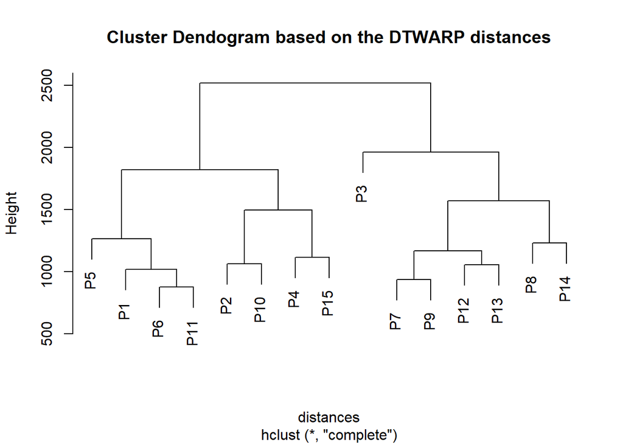

```r
# distances.matrix <- as.matrix(distances)
# heatmap(distances.matrix)


clusters <- hclust(distances)

plot(clusters, hang=0.1, check = TRUE,
     axes = TRUE, ann = TRUE, ylab="Height",
     main = "Cluster Dendogram based on the DTWARP distances")
```

```r
cat("\n")
```

```r
cat(paste0('Based on the above dendogram, one can see that the best choice for total number of clusters is equal to: 3 or 4. This number was then used to cut of the dendogram tree using the  cutree function in R. We show the resulting cluster membership in the table below.'))
```

Based on the above dendogram, one can see that the best choice for total number of clusters is equal to: 3 or 4. This number was then used to cut of the dendogram tree using the cutree function in R. We show the resulting cluster membership in the table below.

```r
cat("\n")
```

```r
clusterCut3 <- cutree(clusters, 3)
clusterCut4 <- cutree(clusters, 4)

cat(paste0('The associated cluster assignments for both thresholds are as follows: \n', 'When using k=3, the assignments are as follows: \n'))
```

```r
kable(clusterCut3) %>% column_spec(1, bold = T, width = "5em") %>% kable_styling(bootstrap_options = "striped", full_width = F)
```

|  | x |
| --- | --- |
| P1 | 1 |
| P2 | 1 |
| P3 | 2 |
| P4 | 1 |
| P5 | 1 |
| P6 | 1 |
| P7 | 3 |
| P8 | 3 |
| P9 | 3 |
| P10 | 1 |
| P11 | 1 |
| P12 | 3 |
| P13 | 3 |
| P14 | 3 |
| P15 | 1 |

```r
#cat(paste0(' \n', 'On the other hand, when k=4, the following assignments were made: \n'))

#kable(clusterCut4) %>% column_spec(1, bold = T, width = "5em") %>% kable_styling(bootstrap_options = "striped", full_width = F)

cat("\n")
```

```r
save(clusterCut3, clusterCut4, pc_prop_var_explained_scaled,
     file = "./Data/RGenerated/ScaledPcaClusters.RData")
```

## 5.1 Presenting TimeSeries Clustering Results with Demographic Information

We provide the overall result of clustering by overlaying the graphs of features and subjective rating of RPE for each cluster, i.e. C1 and C3. The graphical results are provided in the following section in terms of percent task completion (0-100%) for each subject.

```r
load(file = "./Data/RGenerated/NormMedianFilteredData.RData")
load(file = "./Data/RGenerated/ScaledPcaClusters.RData")

RPE = read.csv("https://raw.githubusercontent.com/fmegahed/fatigue-changepoint/master/Data/Raw/RPE.csv") # to read subjective rating of RPE data from GitHub'
colnames(RPE)[1] <- "time.from.start"
df_RPE_transformed <- melt(RPE,
                           id.vars = "time.from.start",
                           measure.vars = colnames(RPE)[2:16])
df_RPE_transformed[,2] <- paste0("RPE.",df_RPE_transformed[,2])
df_RPE_transformed$newcolumn <- "RPE"
colnames(df_RPE_transformed)[4] <- "feature"

clust_1_data <- df_RPE_transformed[FALSE,]
clust_3_data <- df_RPE_transformed[FALSE,]

for (i in 1:15) {
  correct_subject_rows <- which(df_RPE_transformed[,2]==paste0("RPE.Subject.",i))

  dataholder <- get(paste0("subject",i,"_medianf_norm"))
  colnames(dataholder) <- c("time.from.start",
                              paste0("scaled.stride.len.",i),
                              paste0("scaled.stride.height.",i),
                              paste0("stride.duration.",i))

  df_transformed <- melt(dataholder,
                     id.vars = "time.from.start",
                       measure.vars=c(paste0("scaled.stride.len.",i),
                                      paste0("scaled.stride.height.",i),
                                      paste0("stride.duration.",i)
                                      )
                       )
  df_transformed$newcolumn <- c(replicate(2000, "scaled.stride.len"),
                                replicate(2000, "scaled.stride.height"),
                                replicate(2000, "stride.duration"))
  colnames(df_transformed)[4] <- "feature"
  df_transformed <- rbind(df_transformed,df_RPE_transformed[correct_subject_rows,])


  if (clusterCut3[i]==1) {
    clust_1_data <- rbind(clust_1_data,df_transformed)
  } else if (clusterCut3[i]==3) {
    clust_3_data <- rbind(clust_3_data,df_transformed)
  }

}


for (j in c(1,3)) {

  cat('###',paste0("C", j), "{-}",'\n')

  assign(paste0("g",j),
        ggplot(data = get(paste0("clust_",j,"_data")),
               aes(x=time.from.start, y=value, colour = variable)) +
          geom_line(size=1) +
          theme_bw() +
          facet_wrap(~feature,nrow=4, scales = "free_y") +
          labs(title = paste("A paneled time-series plot for cluster",j)) +
          theme(legend.position="none",
                 plot.title = element_text(hjust = 0.5))
      )

      print(get(paste0("g",j)))


      cat("\n \n")
}
```

[output not shown]

### C1

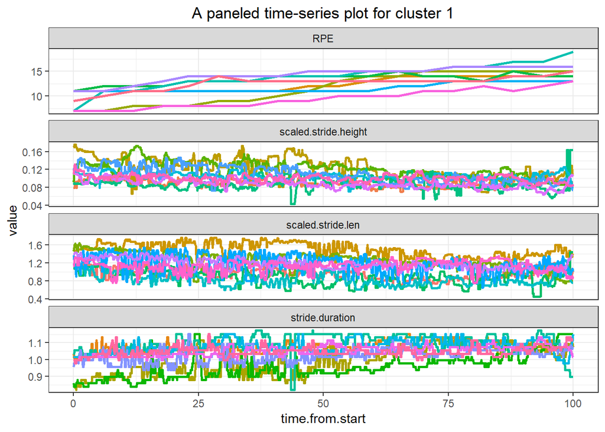